{% raw %}

# 09. Milestone Prokect 2: SkimLit

Our previous 08 NLP project utilized tokenization into embeddings. With this project, we're going to use what was learnt before into practice.

We will replicate deep learning drom this 2017 paper: [PubMed 200k RCT: a Dataset for Sequenctial Sentence Classification in Medical Abstracts.](https://arxiv.org/abs/1710.06071)

The papewr presented with 200,000ish labelled Randomized Controlled Trial (RCT) abstracts. The goal is to explore the abilities of the model in classifying sentences in which order it appears in. Aka, what role does each sentence serve in the abstract?

[figure not shown]

*The example above has the input (which is harder to read), into output (easier to read abstract) of the model we're going to build. The model will take a wall of text, then predict the section label each sentence should have.*

### Problem we're solving

The number of papers released without proper structural abstracts or detail can make ready very hard.

### Solution to said problem

Create an NLP model to abstract sentence's role it plays in the abstract. To enable researchers or other users to skim through literature and dive deeper if necessary. Our model is coming from: [Neural networks for joint sentence classification in medical paper abstracts.](https://arxiv.org/pdf/1612.05251)

### What we're covering

Time to take what was learnt in NLP fundamentals, to create this project:

- Downloading a text dataset (PubMed RCT200k from GitHub)
- Writing a preprocessing function to prepare our data for modelling
- Setting up a series of modelling experiments
  - Make baseline (TF-IDF classifier)
  - Deep models with different combinations of: token embeddings, character embeddings, pretrained embeddings, positional embeddings
- Building our first multimodal model (taking multiple types of data inputs)
  - Replicating the mode architecture from https://arxiv.org/abs/1612.05251
- Find the most wrong predictions
- Making predictions on PubMed abstracts from the wild

```python
import datetime
print(f"Notebook last run (end-to-end): {datetime.datetime.now()}")
```

```
Notebook last run (end-to-end): 2026-01-25 14:20:14.342957
```

```python
# Check for GPU
!nvidia-smi -L
```

```
GPU 0: NVIDIA GeForce GTX 1060 6GB (UUID: GPU-2df24105-ee45-6c5e-c952-e600a0128c08)
```

```python
import tensorflow as tf

print("TensorFlow version:", tf.__version__)
print("GPUs:", tf.config.list_physical_devices('GPU'))
```

```
TensorFlow version: 2.13.0
GPUs: []
```

Even though we have a GPU on our system, our tf does not recognize it. There may be chances that google colab is utilized for this task if training model time is too long.

### Get data

The data can be downloaded from github, which is available as a .txt file. We can copy them to our local directory using: `git clone https://github.com/Franck-Dernoncourt/pubmed-rct`.

```python
!git clone https://github.com/Franck-Dernoncourt/pubmed-rct.git
```

```
fatal: destination path 'pubmed-rct' already exists and is not an empty directory.
```

```python
!dir pubmed-rct
```

```
 Volume in drive F is Extreme SSD
 Volume Serial Number is CE95-62AC

 Directory of f:\main shit\Code stuffz\tensorflow ztm\09 notebook\pubmed-rct

17/01/2026  12:09 pm    <DIR>          .
17/01/2026  12:09 pm    <DIR>          ..
17/01/2026  12:09 pm    <DIR>          PubMed_200k_RCT
17/01/2026  12:09 pm    <DIR>          PubMed_200k_RCT_numbers_replaced_with_at_sign
17/01/2026  12:09 pm    <DIR>          PubMed_20k_RCT
17/01/2026  12:09 pm    <DIR>          PubMed_20k_RCT_numbers_replaced_with_at_sign
17/01/2026  12:09 pm             3,733 README.md
               1 File(s)          3,733 bytes
               6 Dir(s)  1,170,731,958,272 bytes free
```

Looking at the `read_me` file, they are organized between `200k` or `20k` data, or between numbers or numbers replaced with the `@` sign. For us, we're using `20k` data with `@` signs. We're starting small so experiments run quicker. The choice to use `@` is not explained, but my assumption is it adds more continuity for the model, aka it won't interpret the numbers to mean something different than what the sentence implies.

Let's check the file contents.

```python
# check what files are in the PubMed_20K dataset
!dir pubmed-rct\PubMed_20k_RCT_numbers_replaced_with_at_sign
```

```
 Volume in drive F is Extreme SSD
 Volume Serial Number is CE95-62AC

 Directory of f:\main shit\Code stuffz\tensorflow ztm\09 notebook\pubmed-rct\PubMed_20k_RCT_numbers_replaced_with_at_sign

17/01/2026  12:09 pm    <DIR>          .
17/01/2026  12:09 pm    <DIR>          ..
17/01/2026  12:09 pm         4,880,409 dev.txt
17/01/2026  12:09 pm         4,846,504 test.txt
17/01/2026  12:09 pm        29,118,832 train.txt
               3 File(s)     38,845,745 bytes
               2 Dir(s)  1,170,731,958,272 bytes free
```

We have three separate text files:

- `train.txt` - training samples
- `dev.txt` - dev is short for development set, another name for validation set
- `test.txt` - test samples.

To save time, we'll type filepath into a variable.

```python
# Start by using the 20k dataset
data_dir = "pubmed-rct/PubMed_20k_RCT_numbers_replaced_with_at_sign/"
```

```python
# check all of the filenames in the target directory
import os
filenames = [data_dir + filename for filename in os.listdir(data_dir)]
filenames
```

```
['pubmed-rct/PubMed_20k_RCT_numbers_replaced_with_at_sign/dev.txt',
 'pubmed-rct/PubMed_20k_RCT_numbers_replaced_with_at_sign/test.txt',
 'pubmed-rct/PubMed_20k_RCT_numbers_replaced_with_at_sign/train.txt']
```

### Preprocess data

Now we've downloaded the data, we also should visualize and check the data first. Get familiar and understand how we have to prepare our data for our deep learning model.

Because our data is in the form of text files, let's write code to read each of the lines in a target file.

```python
# create function to read the lines of a document
def get_lines(filename):
    '''
    Reads filename (a text file) and returns the lines of text as a list.

    Args:
        filename: a string containing the target filepath to read.

    Returns:
        A list of strings with one string per line from the target filename.
        For example:
        ['this is the first line of filename',
        'this is the second line of filename',
        '...']
    '''
    with open(filename,'r') as f: # open() has few xtra variables. 'r' = read file only
        return f.readlines()
```

We've got a function `get_lines()` which takes the filepath of a text file, opens it, reads each of the line and returns them. Let's try it out on `train.txt`.

```python
train_lines = get_lines(data_dir+'train.txt')
train_lines[:20] # the whole first example of an abstract + a little more of the next one
```

```
['###24293578\n',
 'OBJECTIVE\tTo investigate the efficacy of @ weeks of daily low-dose oral prednisolone in improving pain , mobility , and systemic low-grade inflammation in the short term and whether the effect would be sustained at @ weeks in older adults with moderate to severe knee osteoarthritis ( OA ) .\n',
 'METHODS\tA total of @ patients with primary knee OA were randomized @:@ ; @ received @ mg/day of prednisolone and @ received placebo for @ weeks .\n',
 'METHODS\tOutcome measures included pain reduction and improvement in function scores and systemic inflammation markers .\n',
 'METHODS\tPain was assessed using the visual analog pain scale ( @-@ mm ) .\n',
 'METHODS\tSecondary outcome measures included the Western Ontario and McMaster Universities Osteoarthritis Index scores , patient global assessment ( PGA ) of the severity of knee OA , and @-min walk distance ( @MWD ) .\n',
 'METHODS\tSerum levels of interleukin @ ( IL-@ ) , IL-@ , tumor necrosis factor ( TNF ) - , and high-sensitivity C-reactive protein ( hsCRP ) were measured .\n',
 'RESULTS\tThere was a clinically relevant reduction in the intervention group compared to the placebo group for knee pain , physical function , PGA , and @MWD at @ weeks .\n',
 'RESULTS\tThe mean difference between treatment arms ( @ % CI ) was @ ( @-@ @ ) , p < @ ; @ ( @-@ @ ) , p < @ ; @ ( @-@ @ ) , p < @ ; and @ ( @-@ @ ) , p < @ , respectively .\n',
 'RESULTS\tFurther , there was a clinically relevant reduction in the serum levels of IL-@ , IL-@ , TNF - , and hsCRP at @ weeks in the intervention group when compared to the placebo group .\n',
 'RESULTS\tThese differences remained significant at @ weeks .\n',
 'RESULTS\tThe Outcome Measures in Rheumatology Clinical Trials-Osteoarthritis Research Society International responder rate was @ % in the intervention group and @ % in the placebo group ( p < @ ) .\n',
 'CONCLUSIONS\tLow-dose oral prednisolone had both a short-term and a longer sustained effect resulting in less knee pain , better physical function , and attenuation of systemic inflammation in older patients with knee OA ( ClinicalTrials.gov identifier NCT@ ) .\n',
 '\n',
 '###24854809\n',
 'BACKGROUND\tEmotional eating is associated with overeating and the development of obesity .\n',
 'BACKGROUND\tYet , empirical evidence for individual ( trait ) differences in emotional eating and cognitive mechanisms that contribute to eating during sad mood remain equivocal .\n',
 'OBJECTIVE\tThe aim of this study was to test if attention bias for food moderates the effect of self-reported emotional eating during sad mood ( vs neutral mood ) on actual food intake .\n',
 'OBJECTIVE\tIt was expected that emotional eating is predictive of elevated attention for food and higher food intake after an experimentally induced sad mood and that attentional maintenance on food predicts food intake during a sad versus a neutral mood .\n',
 'METHODS\tParticipants ( N = @ ) were randomly assigned to one of the two experimental mood induction conditions ( sad/neutral ) .\n']
```

Reading the extract of text, the sentences in the sample contains the role each sentence plays in the abstract. The text separates the label with the text with `tab \t`, and each sentence finishes with `new line \n`.

Each abstract also has an ID number, beginning with `###`, then followed by `\n`.

Knowing this, we got a couple of steps to perform to get the data properly prepeared for ML model.

Let's write a function to perform the following steps:

- Take target file of text/abstract samples.
- Read the lines in target file.
- For each line in the target file:
  - If the line begins with `###`, mark as abstract ID and the beginning of a new abstract.
    - Keep count of the number of lines in the abstract.
  - If line begins with `\n`, mark it as the end of a text sample.
    - Keep count of total lines in the abstract sample.
  - Record the text before the `\t`, as the label of the line.
  - Record the text after the `\t`, as the text of the line.
- Return all of the lines in the target text file as dictionary list, containing the key/value pairs:
  - `'line_number'` - the position of the line in the abstract (e.g. 3).
  - `'target'` - the role of the line in the abstract (r.g. OBJECTIVE).
  - `'text'` - the text of the line in the abstract.
  - `'total_lines'` - the total lines in an abstract sample (e.g. 14).
- Abstract IDs and newlines should be omitted from the returned preprocessed data.

Example returned preprocessed sample (a single line from an abstract):

```
[{'line_number': 0,
  'target': 'OBJECTIVE',
  'text': 'to investigate the efficacy of @ weeks of daily low-dose oral prednisolone in improving pain , mobility , and systemic low-grade inflammation in the short term and whether the effect would be sustained at @ weeks in older adults with moderate to severe knee osteoarthritis ( oa ) .',
  'total_lines': 11},
  ...]
```

```python
def preprocess_text_with_line_numbers(filename):
    ''' Returns list of dictionaries of abstract line data.

    Takes filenamee, reads contents and sorts through each line, extracting things like the target label,
    text of sentence, how many sentences are in the current abstract and what sentence number the target line in.

    Args:
        filename: a string of the target text file to read and extract line data from.

    Returns:
        A list of dictionaries each containing a line from an abstract, the lines label, the lines position
        in the abstract and the total number of lines in the abstract where the line is from. For example:

        [{'target': 'CONCLUSION',
          'text': The study couldn't have gone better, turns out people are kinder than you think",
          "line_number": 8,
          "total_lines": 8}]
    '''
    input_lines=get_lines(filename) # get all lines from filename
    abstract_lines='' # create an empty abstract
    abstract_samples=[] # create an empty list of abstracts

    # loop through each line in target file, and processes text data on a single abstract one by one
    for line in input_lines:
        if line.startswith('###'): # check to see if line is an ID line, AKA our starting 'abstract'
            abstract_id=line # keep abstract ID here
            abstract_lines = '' # reset abstract string for gathering of future text

        elif line.isspace(): # check to see if the line given is ONLY whitespace ' ', '\n', '\t', or '\r' is present. This is indication that our abstract has ended
            abstract_line_split=abstract_lines.splitlines() # split abstract into separate lines once it sees typical line breaks of '\n' or '\r'

            # Iterate through each line in abstract and count them at the same time
            for abstract_line_number,abstract_line in enumerate(abstract_line_split):
                line_data={} # create empty dict to store data from line
                target_text_split=abstract_line.split('\t') # split target label from text by identifying '\t'
                line_data['target']=target_text_split[0] # get target label
                line_data['text']=target_text_split[1].lower() # get target text and keep lowercase
                line_data['line_number']=abstract_line_number # what number line does the line appear in the abstract?
                line_data['total_lines']=len(abstract_line_split)-1 # how many total lines are in the abstract, start from 0 due to index
                abstract_samples.append(line_data) # add line data to abstract samples list

        else: # if it doesn't detect single whitespace (\n) in elif, append it into a string with prev results, where processing of current abstract will happen until elif conditions
            abstract_lines+=line

    return abstract_samples
```

Let's now use it to preprocess each of our RCT 20k datasets.

```python
# get data from file and preprocess it
import time
start = time.time()

train_samples = preprocess_text_with_line_numbers(data_dir+'train.txt')
val_samples = preprocess_text_with_line_numbers(data_dir+'dev.txt') # dev is another name for validation data
test_samples = preprocess_text_with_line_numbers(data_dir+'test.txt')

end = time.time()
print("Execution time:", end - start, "seconds")
len(train_samples),len(val_samples),len(test_samples)
```

```
Execution time: 0.7328519821166992 seconds
```

```
(180040, 30212, 30135)
```

Let's check our training samples

```python
# check the first abstract of our training data
train_samples[:14]
```

```
[{'target': 'OBJECTIVE',
  'text': 'to investigate the efficacy of @ weeks of daily low-dose oral prednisolone in improving pain , mobility , and systemic low-grade inflammation in the short term and whether the effect would be sustained at @ weeks in older adults with moderate to severe knee osteoarthritis ( oa ) .',
  'line_number': 0,
  'total_lines': 11},
 {'target': 'METHODS',
  'text': 'a total of @ patients with primary knee oa were randomized @:@ ; @ received @ mg/day of prednisolone and @ received placebo for @ weeks .',
  'line_number': 1,
  'total_lines': 11},
 {'target': 'METHODS',
  'text': 'outcome measures included pain reduction and improvement in function scores and systemic inflammation markers .',
  'line_number': 2,
  'total_lines': 11},
 {'target': 'METHODS',
  'text': 'pain was assessed using the visual analog pain scale ( @-@ mm ) .',
  'line_number': 3,
  'total_lines': 11},
 {'target': 'METHODS',
  'text': 'secondary outcome measures included the western ontario and mcmaster universities osteoarthritis index scores , patient global assessment ( pga ) of the severity of knee oa , and @-min walk distance ( @mwd ) .',
  'line_number': 4,
  'total_lines': 11},
 {'target': 'METHODS',
  'text': 'serum levels of interleukin @ ( il-@ ) , il-@ , tumor necrosis factor ( tnf ) - , and high-sensitivity c-reactive protein ( hscrp ) were measured .',
  'line_number': 5,
  'total_lines': 11},
 {'target': 'RESULTS',
  'text': 'there was a clinically relevant reduction in the intervention group compared to the placebo group for knee pain , physical function , pga , and @mwd at @ weeks .',
  'line_number': 6,
  'total_lines': 11},
 {'target': 'RESULTS',
  'text': 'the mean difference between treatment arms ( @ % ci ) was @ ( @-@ @ ) , p < @ ; @ ( @-@ @ ) , p < @ ; @ ( @-@ @ ) , p < @ ; and @ ( @-@ @ ) , p < @ , respectively .',
  'line_number': 7,
  'total_lines': 11},
 {'target': 'RESULTS',
  'text': 'further , there was a clinically relevant reduction in the serum levels of il-@ , il-@ , tnf - , and hscrp at @ weeks in the intervention group when compared to the placebo group .',
  'line_number': 8,
  'total_lines': 11},
 {'target': 'RESULTS',
  'text': 'these differences remained significant at @ weeks .',
  'line_number': 9,
  'total_lines': 11},
 {'target': 'RESULTS',
  'text': 'the outcome measures in rheumatology clinical trials-osteoarthritis research society international responder rate was @ % in the intervention group and @ % in the placebo group ( p < @ ) .',
  'line_number': 10,
  'total_lines': 11},
 {'target': 'CONCLUSIONS',
  'text': 'low-dose oral prednisolone had both a short-term and a longer sustained effect resulting in less knee pain , better physical function , and attenuation of systemic inflammation in older patients with knee oa ( clinicaltrials.gov identifier nct@ ) .',
  'line_number': 11,
  'total_lines': 11},
 {'target': 'BACKGROUND',
  'text': 'emotional eating is associated with overeating and the development of obesity .',
  'line_number': 0,
  'total_lines': 10},
 {'target': 'BACKGROUND',
  'text': 'yet , empirical evidence for individual ( trait ) differences in emotional eating and cognitive mechanisms that contribute to eating during sad mood remain equivocal .',
  'line_number': 1,
  'total_lines': 10}]
```

Let's look at our `preprocess_text_with_line_numbers()` function worked great.

How about we turn our list of dictionaries into pandas df so we can visualize them better?

```python
import pandas as pd
train_df = pd.DataFrame(train_samples)
val_df = pd.DataFrame(val_samples)
test_df = pd.DataFrame(test_samples)
train_df.head(14)
```

|  | target | text | line_number | total_lines |
| --- | --- | --- | --- | --- |
| 0 | OBJECTIVE | to investigate the efficacy of @ weeks of dail... | 0 | 11 |
| 1 | METHODS | a total of @ patients with primary knee oa wer... | 1 | 11 |
| 2 | METHODS | outcome measures included pain reduction and i... | 2 | 11 |
| 3 | METHODS | pain was assessed using the visual analog pain... | 3 | 11 |
| 4 | METHODS | secondary outcome measures included the wester... | 4 | 11 |
| 5 | METHODS | serum levels of interleukin @ ( il-@ ) , il-@ ... | 5 | 11 |
| 6 | RESULTS | there was a clinically relevant reduction in t... | 6 | 11 |
| 7 | RESULTS | the mean difference between treatment arms ( @... | 7 | 11 |
| 8 | RESULTS | further , there was a clinically relevant redu... | 8 | 11 |
| 9 | RESULTS | these differences remained significant at @ we... | 9 | 11 |
| 10 | RESULTS | the outcome measures in rheumatology clinical ... | 10 | 11 |
| 11 | CONCLUSIONS | low-dose oral prednisolone had both a short-te... | 11 | 11 |
| 12 | BACKGROUND | emotional eating is associated with overeating... | 0 | 10 |
| 13 | BACKGROUND | yet , empirical evidence for individual ( trai... | 1 | 10 |

Now our data is in df form, we can perform some data analysis.

```python
# distribution of labels in training data
train_df.target.value_counts()
```

```
target
METHODS        59353
RESULTS        57953
CONCLUSIONS    27168
BACKGROUND     21727
OBJECTIVE      13839
Name: count, dtype: int64
```

`METHOD` label is most common, compared to `OBJECTIVE` being least common in train data. Why not we check distribution of abstract length?

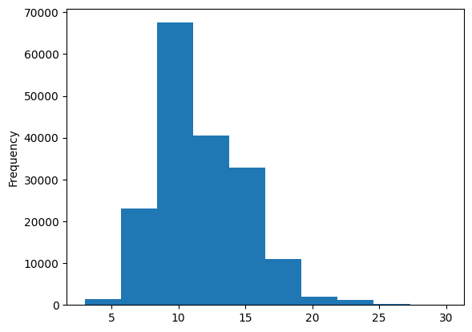

```python
train_df.total_lines.plot.hist();
```

Most of our abstract length is between 7 to 15 lines long. Looking at the `mode` as well, it sits around 10 lines per abstract.

Given we have ~180,000 data points in train, with `20k rct`, it's accurate to say we have roughly 20,000 abstracts.

These things are good to check for outliers/outlandish data points.

### Get list of sentences

When building our deep learning model, its main inputs will be a list of strings (the lines of the abstract). We can do this by calling `tolist()` method on out `text` columns.

```python
# convert abstract text lines into lists
train_sentences=train_df['text'].tolist()
val_sentences=val_df['text'].tolist()
test_sentences=test_df['text'].tolist()
len(train_sentences),len(val_sentences),len(test_sentences)
```

```
(180040, 30212, 30135)
```

```python
# view first 14 lines of training sentence list
train_sentences[:14]
```

```
['to investigate the efficacy of @ weeks of daily low-dose oral prednisolone in improving pain , mobility , and systemic low-grade inflammation in the short term and whether the effect would be sustained at @ weeks in older adults with moderate to severe knee osteoarthritis ( oa ) .',
 'a total of @ patients with primary knee oa were randomized @:@ ; @ received @ mg/day of prednisolone and @ received placebo for @ weeks .',
 'outcome measures included pain reduction and improvement in function scores and systemic inflammation markers .',
 'pain was assessed using the visual analog pain scale ( @-@ mm ) .',
 'secondary outcome measures included the western ontario and mcmaster universities osteoarthritis index scores , patient global assessment ( pga ) of the severity of knee oa , and @-min walk distance ( @mwd ) .',
 'serum levels of interleukin @ ( il-@ ) , il-@ , tumor necrosis factor ( tnf ) - , and high-sensitivity c-reactive protein ( hscrp ) were measured .',
 'there was a clinically relevant reduction in the intervention group compared to the placebo group for knee pain , physical function , pga , and @mwd at @ weeks .',
 'the mean difference between treatment arms ( @ % ci ) was @ ( @-@ @ ) , p < @ ; @ ( @-@ @ ) , p < @ ; @ ( @-@ @ ) , p < @ ; and @ ( @-@ @ ) , p < @ , respectively .',
 'further , there was a clinically relevant reduction in the serum levels of il-@ , il-@ , tnf - , and hscrp at @ weeks in the intervention group when compared to the placebo group .',
 'these differences remained significant at @ weeks .',
 'the outcome measures in rheumatology clinical trials-osteoarthritis research society international responder rate was @ % in the intervention group and @ % in the placebo group ( p < @ ) .',
 'low-dose oral prednisolone had both a short-term and a longer sustained effect resulting in less knee pain , better physical function , and attenuation of systemic inflammation in older patients with knee oa ( clinicaltrials.gov identifier nct@ ) .',
 'emotional eating is associated with overeating and the development of obesity .',
 'yet , empirical evidence for individual ( trait ) differences in emotional eating and cognitive mechanisms that contribute to eating during sad mood remain equivocal .']
```

Now we have a list of all the text sentences, each with its own index number.

Since we've separated our df with text data, we'll need to rite code to convert the text to numbers before ML can learn, as it can't read letters. Only numbers.

### Make numeric labels (ML models require numeric labels)

We're going to create one hot and label encoded labels.

We could try with label encoded labels. (Aka 0=dog, 1=cat, 2=chinchilla), but tf `CategoricalCrossentropy` loss function likes to have one hot encoded labels, which also allows us to use label smoothing later on.

To do this, we will use `OneHotEncoder` and `LabeEncoder` classes.

```python
# one how encode labels
from sklearn.preprocessing import OneHotEncoder

one_hot_encoder = OneHotEncoder(sparse_output=False)
train_labels_one_hot = one_hot_encoder.fit_transform(train_df['target'].to_numpy().reshape(-1,1))
                                                    # get our target column from train df
                                                                        # convert pd dataframe into numpy array, as scikit_learn expects it/cannot understand pandas df
                                                                                    # before = (4,) > after = (4,1) - extra dim required as sklearn expects 2d input shaped as (x_samples,x_features)
                                                                                    # -1 means 'conclude number of rows as is/automatically (since it's getting the last index value of item)'
                                      # encoder learns all unique categories from 'target'
val_labels_one_hot = one_hot_encoder.fit_transform(val_df['target'].to_numpy().reshape(-1,1))
test_labels_one_hot = one_hot_encoder.fit_transform(test_df['target'].to_numpy().reshape(-1,1))

# check what training labels look like
train_labels_one_hot
```

```
array([[0., 0., 0., 1., 0.],
       [0., 0., 1., 0., 0.],
       [0., 0., 1., 0., 0.],
       ...,
       [0., 0., 0., 0., 1.],
       [0., 1., 0., 0., 0.],
       [0., 1., 0., 0., 0.]])
```

> **Why does OneHotEncoding need a features column?**

OneHotEncoding is often used for feature based labelling, where not only do you have a category that you one hot encode into, but also another column that has details of the feature of said categories present in the data.

It's fine if you have one categorical feature such as: `cat, dog, fish`, which will give you something like >

```
cat  dog  fish
1    0    0
0    1    0
0    0    1
```

Now in the case of multiple categorical features:

```
color   size
red     M
blue    L
green   S
```

Each feature is encoded separately. But because there are two labels for one row, you get two `1s` in the one hot encoded row. But it's only two each specific features:

```
color_red  color_blue  color_green  size_S  size_M  size_L
1          0           0             0       1       0
0          1           0             0       0       1
0          0           1             1       0       0
```

So naturally, you won't recieve two `1s` on color. Only one `1` on each feature listed.

You can have as many features as needed, so intead of `color` and `size`, (x,2) - you can have `origin` as well (x,3) and so on. Your unique number of features is going to be that second number.

### Label encode labels

```python
# extract labels ('target' columns) and encode them into integers
from sklearn.preprocessing import LabelEncoder

label_encoder = LabelEncoder()
train_labels_encoded = label_encoder.fit_transform(train_df['target'].to_numpy())
val_labels_encoded = label_encoder.fit_transform(val_df['target'].to_numpy())
test_labels_encoded = label_encoder.fit_transform(test_df['target'].to_numpy())

# check what training labels look like
train_labels_encoded
```

```
array([3, 2, 2, ..., 4, 1, 1])
```

Let's also get the class names using the `classes_` attribute.

```python
# Get class names and number of classes from LabelEncoder instance
num_classes = len(label_encoder.classes_)
class_names = label_encoder.classes_
num_classes, class_names
```

```
(5,
 array(['BACKGROUND', 'CONCLUSIONS', 'METHODS', 'OBJECTIVE', 'RESULTS'],
       dtype=object))
```

## Model 0: Getting baseline model

Our first model will be TF-IDF Multinomial Naive Bayes, which is recommended from sklearn's ml map. https://scikit-learn.org/stable/machine_learning_map.html

To build, we need to use sklearn's pipeline which uses `TfidfVectorizer` class to convert our abstract sentences to numbers using the TF-IDF (term frequency-inverse document frequency) algorithm and then learns to classify our sentences using the `MultinomialNB` algorithm.

> How does TF-IDF convert sentences to numbers?

TF-IDF assesses how often a word appears in the single line, and also overall dataset, giving two separate data values that is combined together to give a value.

```
TF–IDF Scenarios (per word, per document)

1) LOW TF × LOW IDF  → VERY LOW TF-IDF
   - Word appears rarely in this abstract
   - Word appears in many documents across the corpus
   - Example: stopwords or filler terms ('the', 'a', 'or')
   - Interpretation: not important to this document

2) HIGH TF × LOW IDF → LOW TF-IDF
   - Word appears frequently in this abstract
   - Word appears in many documents across the corpus
   - Example: domain-common words (e.g. "study", "results", "variable" in research papers)
   - Interpretation: common but not discriminative

3) LOW TF × HIGH IDF → MEDIUM TF-IDF
   - Word appears rarely in this abstract
   - Word appears in very few documents across the corpus
   - Example: rare but incidental terms (e.g. "scrumptious", "homosexual")
   - Interpretation: distinctive but not central

4) HIGH TF × HIGH IDF → HIGH TF-IDF
   - Word appears frequently in this abstract
   - Word appears in very few documents across the corpus
   - Example: document-specific keywords
   - Interpretation: highly informative and discriminative
```

- TF asks: "Is this word important to THIS abstract?"
- IDF asks: "Is this word unique compared to OTHER abstracts in the entirety of data?"
- TF-IDF rewards words that answer "yes" to both.

> Note: In practice, IDF (looking at word uniquness amongst whole dataset) often has more weight than TF (looking at abstract only for such words), because of it's broad reach on all data, rather than single isolated sections.

```python
from sklearn.feature_extraction.text import TfidfVectorizer
from sklearn.naive_bayes import MultinomialNB
from sklearn.pipeline import Pipeline

# create a pipeline
model_0 = Pipeline([
    ('tf-idf',TfidfVectorizer()),
    ('clf',MultinomialNB())
])

# fits the pipeline to the training data
model_0.fit(X=train_sentences,
            y=train_labels_encoded);
```

Due to the speed of NB algorithm, it trains very quickly. Let's evaluate data using `score()` method.

```python
# evaluate baseline on val
model_0.score(X=val_sentences,
              y=val_labels_encoded)
```

```
0.7218323844829869
```

Our number to beat will be 72.1% accuracy on validation.

Now let's make some prediction with our baseline to further evaluate it.

```python
# make predictions
baseline_preds = model_0.predict(val_sentences)
baseline_preds
```

```
array([4, 1, 3, ..., 4, 4, 1])
```

For evaluation metrics, we can import `calculate_results()` function from the `helper_functions.py` script to compare them to true labels. We will obtain the following:

Accuracy, Precision, Recall, F1-Score

### Download helper script

```python
# Download helper functions script
!curl -O https://raw.githubusercontent.com/mrdbourke/tensorflow-deep-learning/main/extras/helper_functions.py
```

```
  % Total    % Received % Xferd  Average Speed   Time    Time     Time  Current
                                 Dload  Upload   Total   Spent    Left  Speed

  0     0    0     0    0     0      0      0 --:--:-- --:--:-- --:--:--     0
100 10246  100 10246    0     0  27105      0 --:--:-- --:--:-- --:--:-- 27322
```

Now we got the helper functions downloaded, we can import `calculate_results()` function and see how baseline performed of the above 4 metrics.

```python
# import calculate results from helper function
from helper_functions import calculate_results

baseline_results = calculate_results(y_true=val_labels_encoded,
                                     y_pred=baseline_preds)
baseline_results
```

```
{'accuracy': 72.1832384482987,
 'precision': 0.7186466952323352,
 'recall': 0.7218323844829869,
 'f1': 0.6989250353450294}
```

### Preparing our data for deep sequence models

Sweet, we've got a working baseline model to one up it. We would also need to make vectorization + embedding layers for other deeper models.

We will start with importing appropriate libraries to do said vectors and embedding. Namely tf and Numpy

```python
import numpy as np
import tensorflow as tf
from tensorflow.keras import layers
```

Since we'll be turning sentences into numbers, it's a good idea to figure out how many words are in each sentence.

When a model goes through each sentences, they do best with a standardized length (aka same length of words per sentence). Which is important for creating batches of the same size tensors.

If we have a sentence of 8 words, but standardized to 16 words long, we want to pad the later options with zeroes to keep it 16 'words' long.

Let's write some code to find average length of sentence to be our standardized length.

```python
# how long is each sentence average?
line_len=[len(sentence.split()) for sentence in train_sentences]
avg_line_len=np.mean(line_len)
avg_line_len # return average setence length
```

```
26.338269273494777
```

Let's also check distribution lengths:

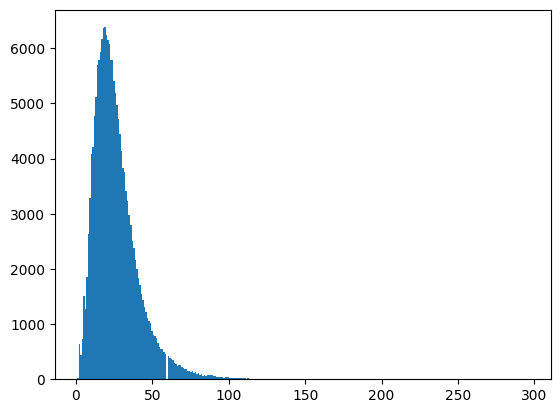

```python
# what's the distribution look like?
import matplotlib.pyplot as plt
plt.hist(line_len,bins=300);
```

Data shows most of the length is within 0 to 50 words long, with the mode lining quite close to that `26` number we got from average text length.

We can also use Numpy's `percentile` to find the value that covers up to 95% of sentence length.

```python
# How long of a sentence covers 95% of the length?
output_seq_len = int(np.percentile(line_len,95))
output_seq_len
```

```
55
```

95% of sentences have lengths of 55 tokens or less.

To standardize our length, we will set it as 55 tokens long, meaning any sentences shorter than 55 tokens long would be padded up with 0, and anything longer are truncated down to 55.

But why 95%? Let's check the max line length.

```python
max(line_len)
```

```
296
```

Since hardly any sentence length reach to 296, meaning majority of the data we pass to the model would be zeroes.

But we also want majority of the details from said sentence still be retained, while still being efficient storage and performance wise with data.

So this is our rough guesstimation for standardized token length.

### Create text vectorizer

Let's vectorize our 55 lengthed sentences using `TextVectorization` layer from tf.

All parameters are kept except `max_tokens` (the number of unique words in our dataset) and `output_sequence_length` (our desired output length for each vectorized sentence).

The paper states our dataset vocab sized is 68,000, so we'll use that as our `max_tokens` parameter.

```python
# how many words in our vocab of data?
max_tokens=68000
```

Since discovering sentence length of 55 or under is 95% of training sentences, we're using that as `output_sequence_length`.

```python
from tensorflow.keras.layers import TextVectorization

text_vectorizer = TextVectorization(max_tokens=max_tokens,
                                     output_sequence_length=55)
```

Our vectorization is done, so we can let it adapt to our training data (aka how it chooses to represent what number is with what word), then test it out.

```python
# adapt text vectorizer to training sentences
text_vectorizer.adapt(train_sentences)
```

```python
# test out text vectorizer
import random
target_sentence = random.choice(train_sentences)
print(f'Text:\n{target_sentence}')
print(f'\nLength of text: {len(target_sentence.split())}')
print(f'\nVectorized text:\n{text_vectorizer([target_sentence])}')
```

```
Text:
a treatment that does this , metacognitive therapy ( mct ) , underwent preliminary controlled evaluation in this study .

Length of text: 20

Vectorized text:
[[    8    19    28   711    23 11987    66  5987   352  1674   106   381
      5    23    17     0     0     0     0     0     0     0     0     0
      0     0     0     0     0     0     0     0     0     0     0     0
      0     0     0     0     0     0     0     0     0     0     0     0
      0     0     0     0     0     0     0]]
```

'@' Is not counted as word for our vocab, therefore ignored since it's a symbol.

Now we have a way to convert sequences into numbers. We can use `get_vocabulary()` method of our `text_vectorizer` to find our different tidbits about our text.

```python
# how many words in our training vocab
rct_20k_text_vocab = text_vectorizer.get_vocabulary()
print(f'Number of words in vocabulary: {len(rct_20k_text_vocab)}')
print(f'Most common words in the vocabulary: {rct_20k_text_vocab[:5]}')
print(f'Least common words in the vocabulary: {rct_20k_text_vocab[-5:]}')
```

```
Number of words in vocabulary: 64841
Most common words in the vocabulary: ['', '[UNK]', 'the', 'and', 'of']
Least common words in the vocabulary: ['aainduced', 'aaigroup', 'aachener', 'aachen', 'aaacp']
```

And if we wanted to figure out the configuration of our `text_vectorizer`, we can use the `get_config()` method.

```python
# get the config of our text vectorizer
text_vectorizer.get_config()
```

```
{'name': 'text_vectorization',
 'trainable': True,
 'dtype': 'string',
 'batch_input_shape': (None,),
 'max_tokens': 68000,
 'standardize': 'lower_and_strip_punctuation',
 'split': 'whitespace',
 'ngrams': None,
 'output_mode': 'int',
 'output_sequence_length': 55,
 'pad_to_max_tokens': False,
 'sparse': False,
 'ragged': False,
 'vocabulary': None,
 'idf_weights': None,
 'encoding': 'utf-8',
 'vocabulary_size': 64841}
```

### Create custom embeddings

Vectors are only the beginning of representation of words, but not relationships. This is what embedding does, where they can map relationships with every unique token, which will update as the model learns.

We can create the embedding layer with tf's `Embedding` layer.

The main parameters we're concerned with our inputs and outputs of `Embedding` layer.

- `input_dim` > defines size of our vocab
- `output_dim` > defines the dimension of embedding output

Our embedding created will use integer outputs from our vectorization layer as the inputs, then convert them to feature vectors of size `output_dim`.

```python
# create token embedding layer
token_embed = layers.Embedding(input_dim=len(rct_20k_text_vocab), # length of vocab
                               output_dim=128, # different embedding size gives drastically different numbers of params
                               # use masking to handle variable sequence lengths (save space)
                               mask_zero=True,
                               name='token_embedding')

# show example embedding
print(f'Sentence before vectorization:\n{target_sentence}\n')
vectorized_sentence = text_vectorizer([target_sentence])
print(f'Sentence after vectorization (before embedding):\n{vectorized_sentence}\n')
embedded_sentence = token_embed(vectorized_sentence)
print(f'Sentence after embedding:\n{embedded_sentence}\n')
print(f'Embedded sentence shape: {embedded_sentence.shape}')
```

```
Sentence before vectorization:
a treatment that does this , metacognitive therapy ( mct ) , underwent preliminary controlled evaluation in this study .

Sentence after vectorization (before embedding):
[[    8    19    28   711    23 11987    66  5987   352  1674   106   381
      5    23    17     0     0     0     0     0     0     0     0     0
      0     0     0     0     0     0     0     0     0     0     0     0
      0     0     0     0     0     0     0     0     0     0     0     0
      0     0     0     0     0     0     0]]

Sentence after embedding:
[[[ 0.00907128  0.01522399  0.03675095 ... -0.02804158 -0.0480332
   -0.02878345]
  [-0.04950004 -0.01844294 -0.00439204 ...  0.03617293 -0.01550972
    0.03798277]
  [ 0.04690598 -0.03998178 -0.021271   ... -0.04841317 -0.04321688
    0.02048034]
  ...
  [ 0.01622181  0.01014869  0.00396644 ...  0.04987376  0.03534566
    0.0089482 ]
  [ 0.01622181  0.01014869  0.00396644 ...  0.04987376  0.03534566
    0.0089482 ]
  [ 0.01622181  0.01014869  0.00396644 ...  0.04987376  0.03534566
    0.0089482 ]]]

Embedded sentence shape: (1, 55, 128)
```

### Create datasets (ASAP)

We've gone through steps to preprocess the data, however there are still a few steps to make them work faster with our models.

Namely the `tf.data` API provides methods which enable faster data loading.

Main step is to use our data to turn it into a `PrefetchDataset`of batches. Methods used are `batch()` and `prefetch()`, the parameter `tf.data.AUTOTUNE` will also allow tf to determine the optimal amount of computation to prepare dataset.

```python
# turn our data into tf datasets
train_dataset = tf.data.Dataset.from_tensor_slices((train_sentences,train_labels_one_hot))
val_dataset = tf.data.Dataset.from_tensor_slices((val_sentences,val_labels_one_hot))
test_dataset = tf.data.Dataset.from_tensor_slices((test_sentences,test_labels_one_hot))

train_dataset
```

```
<_TensorSliceDataset element_spec=(TensorSpec(shape=(), dtype=tf.string, name=None), TensorSpec(shape=(5,), dtype=tf.float64, name=None))>
```

```python
# take the TensorSliceFatasets and turn them into prefetched batches
train_dataset = train_dataset.batch(32).prefetch(tf.data.AUTOTUNE)
val_dataset = val_dataset.batch(32).prefetch(tf.data.AUTOTUNE)
test_dataset = test_dataset.batch(32).prefetch(tf.data.AUTOTUNE)

train_dataset
```

```
<_PrefetchDataset element_spec=(TensorSpec(shape=(None,), dtype=tf.string, name=None), TensorSpec(shape=(None, 5), dtype=tf.float64, name=None))>
```

### Model 1: Conv1D with token embeddings

Time to build a series of deep models and improve upon baseline. All models will follow a similar structure:

`Input (text) -> Tokenize -> Embedding -> Layers -> Output (label probability)`

The main component being changed throughout is the `layers` component, as that is where all the deep learning model structure sits, and they all often rely on the same preprocessing and building layer blocks as any other model.

Our first model is a 1-dimensional CNN - which we had explored on 08 notebook with our `model_5`. We will following this standard workflow:

`Build model -> Train model -> Evaluate model (make predictions and compare to ground truth)`

```python
# create 1d cnn model to process sequences
inputs = layers.Input(shape=(1,),dtype=tf.string)
text_vectors = text_vectorizer(inputs) # vectorize text inputs
token_embeddings = token_embed(text_vectors) # create embed from vectors
x = layers.Conv1D(filters=64,kernel_size=5,padding='same',activation='relu')(token_embeddings)
# padding='same' > because we have a screening size of '5', aka 5 words are looked at in sequence, when you reach the edge, you would inevitably get 4 words left instead.
# Padding allows model to still read content beyond that kernel size of '5', by padding it with numbers - 'same' leaves the edge cases with '0'.
x = layers.GlobalAveragePooling1D()(x) # condense the output of our feature vector
outputs = layers.Dense(num_classes,activation='softmax')(x)
model_1 = tf.keras.Model(inputs,outputs)

# compile model
model_1.compile(loss='categorical_crossentropy', # when labels are not one hot encoded, use sparse_categorical_crossentropy
                optimizer=tf.keras.optimizers.Adam(),
                metrics=['accuracy'])
```

```python
# get summary of conv1d model
model_1.summary()
```

[output not shown]

Next step is begin fitting of model. Due to our experimentation phase and also extremely large dataset of +180,000 sentences, standard case for this is to only train and validate with 10% of the data from training and validation respectively.

Small experiments keep things running efficient, while also giving us an idea on performance. This also means few epochs as well.

```python
# fit the model
model_1_history = model_1.fit(train_dataset,
                              steps_per_epoch=int(0.1*len(train_dataset)),
                              epochs=3,
                              validation_data=val_dataset,
                              validation_steps=int(0.1*len(val_dataset)))
```

[output not shown]

We've got our first results, and its looking pretty decent for just 3 epochs! Sadly due to hardware limitations, it took significantly longer than baseline.

Let's still evaluate it with full validation dataset

```python
# evaluate on whole validation dataset
model_1.evaluate(val_dataset)
```

```
[0.593546450138092, 0.7882960438728333]
```

```python
# make predictions (our model makes predictions probabilities for every class)
model_1_pred_probs = model_1.predict(val_dataset)
model_1_pred_probs
```

```
array([[4.52656269e-01, 1.61178544e-01, 7.38328248e-02, 2.90207207e-01,
        2.21251305e-02],
       [4.06946003e-01, 3.23774040e-01, 1.20665794e-02, 2.47859702e-01,
        9.35371127e-03],
       [1.22544564e-01, 4.04784735e-03, 1.56036764e-03, 8.71823847e-01,
        2.33457122e-05],
       ...,
       [8.74015495e-06, 7.47744460e-04, 8.87136499e-04, 4.54808287e-06,
        9.98351812e-01],
       [5.25710545e-02, 5.10038733e-01, 8.49502087e-02, 6.39811829e-02,
        2.88458794e-01],
       [1.88149974e-01, 6.74629509e-01, 5.12454361e-02, 4.37470004e-02,
        4.22280096e-02]], dtype=float32)
```

```python
# convert prediction probs into full predictions
model_1_preds = tf.argmax(model_1_pred_probs,axis=1)
model_1_preds
```

```
<tf.Tensor: shape=(30212,), dtype=int64, numpy=array([0, 0, 3, ..., 4, 1, 1], dtype=int64)>
```

```python
# calculate model_1 results
model_1_results = calculate_results(val_labels_encoded,model_1_preds)
model_1_results
```

```
{'accuracy': 78.82960413080895,
 'precision': 0.7858668535487656,
 'recall': 0.7882960413080895,
 'f1': 0.7861354981063134}
```

Baseline results:

```
{'accuracy': 72.1832384482987,
 'precision': 0.7186466952323352,
 'recall': 0.7218323844829869,
 'f1': 0.6989250353450294}
```

### Model 2: Feature Extraction with pretrained token embeddings

The paper that was made for our training data, had used a form of feature extraction, with `pretrained GloVe embedding` to initialise their token embeddings.

We will emulate this by using the `pretrained USE embeddings` from tf. The reason we aren't using `GloVe`, is our primary workspace being in tf. So we'll use whats available for tf.

The model structure should look like the following:

`Inputs (string) -> Pretrained embeddings from TF Hub (Universal Sentence Encoder) -> Layers -> Output (prediction probabilities)

The lack of tokenization use, is only because USE actually does the tokenization for us within it.

Since it's the USE used from notebook 08, we can copy paste the pretrained weights into this folder. Remembering to set `trainable=False`, as this is feature extraction, not fine tuning.

```python
# Download pretrained TensorFlow Hub USE
import tensorflow_hub as hub
tf_hub_embedding_layer = hub.KerasLayer("https://tfhub.dev/google/universal-sentence-encoder/4",
                                        trainable=False,
                                        name="universal_sentence_encoder")
```

```python
# test out embedding on a random sentence
random_training_sentence = random.choice(train_sentences)
print(f'Random training sentence:\n{random_training_sentence}\n')
use_embedded_sentence = tf_hub_embedding_layer([random_training_sentence])
print(f'Sentence after embedding:\n{use_embedded_sentence[0][:30]} (truncated output)...')
print(f'Length of sentence embedding:\n{len(use_embedded_sentence[0])}')
```

```
Random training sentence:
these changes in glycemic control with pa are associated with decreases in insulin and gip concentrations .

Sentence after embedding:
[ 0.06850173  0.0385579  -0.05077641 -0.00767249 -0.07487443  0.069626
  0.02412859 -0.01624908 -0.07457688  0.04895084  0.08426482  0.03610523
  0.02376147  0.05972756 -0.06821115 -0.04529742 -0.08130223  0.00331781
  0.03972075  0.03443268 -0.0096004   0.06410919  0.05472122  0.01480137
  0.06900971  0.00543034 -0.01756855  0.06455053 -0.02364734 -0.00367455] (truncated output)...
Length of sentence embedding:
512
```

As mentioned with USE modeule, the tokenizing of text has a 512 dimensional embedding vector.

Let's put it together and compile a model using our `tf_hub_embedding_layer`.

### Building and fitting an NLP feature extraction model from TensorFlow Hub

```python
# Define feature extractor model using TF HUB layer
inputs = layers.Input(shape=[],dtype=tf.string)
pretrained_embedding = tf_hub_embedding_layer(inputs) # tokenize text and create embedding
x = layers.Dense(128,activation='relu')(pretrained_embedding) # add a fully connected layer on top of the embedding
# Note: you could add more layers here if wanted
outputs = layers.Dense(5,activation='softmax')(x) # create the output layer
model_2 = tf.keras.Model(inputs=inputs,
                         outputs=outputs)

# compile the model
model_2.compile(loss='categorical_crossentropy',
                optimizer=tf.keras.optimizers.Adam(),
                metrics=['accuracy'])
```

```python
# summary of the model
model_2.summary()
```

[output not shown]

Our model has a lot of params, but remember they are frozen. So it's only trainable on dense_1 and dense_2 layers.

```python
# fit feature extractor model for 3 epochs
model_2.fit(train_dataset,
            steps_per_epoch=int(0.1*len(train_dataset)),
            epochs=3,
            validation_data=val_dataset,
            validation_steps=int(0.1*len(val_dataset)))
```

```
<keras.src.callbacks.History at 0x2b293eb2710>
```

```python
# evaluate model
model_2.evaluate(val_dataset)
```

```
[0.7429659962654114, 0.7127300500869751]
```

Our training is quicker because we aren't updating and training the custom embedding layer.

Let's make some predictions and evaluate our feature extraction model.

```python
# make predictions with feature extraction model
model_2_pred_prob = model_2.predict(val_dataset)
model_2_pred_prob
```

```
array([[4.0296492e-01, 3.7861297e-01, 3.0153603e-03, 2.0633686e-01,
        9.0699363e-03],
       [3.3640304e-01, 5.1746267e-01, 4.6536522e-03, 1.3795778e-01,
        3.5228287e-03],
       [2.1578005e-01, 1.3327408e-01, 1.8655987e-02, 5.9029943e-01,
        4.1990407e-02],
       ...,
       [1.8104223e-03, 5.2044108e-03, 5.6882713e-02, 9.2057034e-04,
        9.3518192e-01],
       [3.7999908e-03, 4.1396569e-02, 1.9115110e-01, 1.2854051e-03,
        7.6236689e-01],
       [1.7905509e-01, 1.8700576e-01, 5.5818653e-01, 5.4996465e-03,
        7.0252933e-02]], dtype=float32)
```

```python
# convert prediction probs to class preds
model_2_preds = tf.argmax(model_2_pred_prob,axis=1)
model_2_preds
```

```
<tf.Tensor: shape=(30212,), dtype=int64, numpy=array([0, 1, 3, ..., 4, 4, 2], dtype=int64)>
```

```python
# calculate results
model_2_results=calculate_results(val_labels_encoded,model_2_preds)
model_2_results
```

```
{'accuracy': 71.2730041043294,
 'precision': 0.713185438057974,
 'recall': 0.7127300410432941,
 'f1': 0.709796057882019}
```

### Model 3: Conv1D with character embeddings

**Creating a character-level tokenizer**

The paper that created the data mentions their model uses a hybrid of token and character embeddings.

We've built models with a custom token embedding and pretrained token embedding. The difference between character and token embedding is that the `character embedding` is created using sequence split into characters (3.g. `hello` -> `h`, `e`, `l`, `l`, `o`) whilst `token embedding` is created on sequences split into tokens, aka words.

[figure not shown]

*Token level embeddings split sequences into tokens (words) and embeds each of them, character embeddings split sequences into characters and creates a feature vector for each.*

We can create character-embedding via vectorizing our sequence after splitting into characters using `TextVectorization`. Then passing vectorized sequence to `Embedding` layer.

We will first split them into characters, and will write a function to do so.

```python
# make function to split sentences into characters
def split_chars(text):
    return ' '.join(list(text)) # list(text) splits the string into it's individual characters
                                # .join inserts the ' ' as requested in between all elements (includes whitespaces that already exist in it)

#test splitting non-character-level sequence into characters
split_chars(random_training_sentence)
```

```
't h e s e   c h a n g e s   i n   g l y c e m i c   c o n t r o l   w i t h   p a   a r e   a s s o c i a t e d   w i t h   d e c r e a s e s   i n   i n s u l i n   a n d   g i p   c o n c e n t r a t i o n s   .'
```

Let's now create a preprocessed dataset, that has this character separation next:

```python
# split sequence-level data plits into character-level splits
train_chars = [split_chars(sentence) for sentence in train_sentences]
val_chars = [split_chars(sentence) for sentence in val_sentences]
test_chars = [split_chars(sentence) for sentence in test_sentences]
print(train_chars[0])
```

```
t o   i n v e s t i g a t e   t h e   e f f i c a c y   o f   @   w e e k s   o f   d a i l y   l o w - d o s e   o r a l   p r e d n i s o l o n e   i n   i m p r o v i n g   p a i n   ,   m o b i l i t y   ,   a n d   s y s t e m i c   l o w - g r a d e   i n f l a m m a t i o n   i n   t h e   s …
```

We also need to check how long vector chars are, as distribution is different from token based.

```python
# check average character length
char_lens = [len(sentence) for sentence in train_sentences]
mean_char_len = np.mean(char_lens)
mean_char_len
```

```
149.3662574983337
```

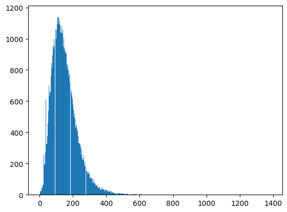

```python
# check distribution of our sequence in char-level
plt.hist(char_lens,bins=1400);
```

Most character length is between 0 to 200. Let's check what length covers 95% of the sentence sequence.

```python
# find out chat char length covers 95% of sequence
output_seq_char_len = int(np.percentile(char_lens,95))
output_seq_char_len
```

```
290
```

Now we know `290` is character length that covers 95% of length, which will be used as `output_sequence_length` in our `TextVectorization`.

```python
# get all keyboard characters for char-level embedding
import string
alphabet = string.ascii_lowercase + string.digits + string.punctuation
alphabet
```

```
'abcdefghijklmnopqrstuvwxyz0123456789!"#$%&\'()*+,-./:;<=>?@[\\]^_`{|}~'
```

```python
# create char-level vectorizer
NUM_CHAR_TOKENS = len(alphabet) + 2 # num characters in alpha + space + OOV token
char_vectorizer = TextVectorization(max_tokens=NUM_CHAR_TOKENS,
                                    output_sequence_length=output_seq_char_len,
                                    standardize='lower_and_strip_punctuation',
                                    name='char_vectorizer')

# adapt character vectorizer to training characters
char_vectorizer.adapt(train_chars)
```

What `lower_and_strip_punctuation` does two things:

- Change any upper to lower case. `e.g 'UPPER' > 'upper'`
- Remove any punctuation present. `[!"#$%&'()*+,-./:;<=>?@[\\\]^_{|}~] > Removed entirely`

Let's now check the characteristics about using it in `get_vocabulary()` method.

```python
# check character vocab characteristics
char_vocab = char_vectorizer.get_vocabulary()
print(f'Number of different characters in character vocab: {len(char_vocab)}')
print(f'5 most common characters: {char_vocab[:5]}')
print(f'5 least common characters: {char_vocab[-5:]}')
```

```
Number of different characters in character vocab: 28
5 most common characters: ['', '[UNK]', 'e', 't', 'i']
5 least common characters: ['k', 'x', 'z', 'q', 'j']
```

We can also text it on random sequence to make sure it is working.

```python
# test out text vectorizer
random_train_chars = random.choice(train_chars)
print(f'Split text:\n{random_train_chars}')
print(f'\nLength of chars: {len(random_train_chars.split())}')
vectorized_chars = char_vectorizer([random_train_chars])
print(f'\nVectorized chars:\n{vectorized_chars}')
print(f'\nLength of vectorized char: {len(vectorized_chars[0])}')
```

```
Split text:
t h e   m e a n   c h a n g e   f r o m   b a s e l i n e   i n   m e a n   d i u r n a l   i o p   (   s t a n d a r d   d e v i a t i o n   )   i n   t h e   b i m a t o p r o s t / t i m o l o l   f i x e d   c o m b i n a t i o n   g r o u p   w a s   (   - @   @   )   m m h g   a n d   i t   w …

Length of chars: 160

Vectorized chars:
[[ 3 13  2 15  2  5  6 11 13  5  6 18  2 17  8  7 15 22  5  9  2 12  4  6
   2  4  6 15  2  5  6 10  4 16  8  6  5 12  4  7 14  9  3  5  6 10  5  8
  10 10  2 21  4  5  3  4  7  6  4  6  3 13  2 22  4 15  5  3  7 14  8  7
   9  3  3  4 15  7 12  7 12 17  4 24  2 10 11  7 15 22  4  6  5  3  4  7
   6 18  8  7 16 14 20  5  9 15 15 13 18  5  6 10  4  3 20  5  9 15 15 13
  18  4  6  3 13  2 11  7  6 11 16  8  8  2  6  3 18  8  7 16 14 14  0  0
   0  0  0  0  0  0  0  0  0  0  0  0  0  0  0  0  0  0  0  0  0  0  0  0
   0  0  0  0  0  0  0  0  0  0  0  0  0  0  0  0  0  0  0  0  0  0  0  0
   0  0  0  0  0  0  0  0  0  0  0  0  0  0  0  0  0  0  0  0  0  0  0  0
   0  0  0  0  0  0  0  0  0  0  0  0  0  0  0  0  0  0  0  0  0  0  0  0
   0  0  0  0  0  0  0  0  0  0  0  0  0  0  0  0  0  0  0  0  0  0  0  0
   0  0  0  0  0  0  0  0  0  0  0  0  0  0  0  0  0  0  0  0  0  0  0  0
   0  0]]

Length of vectorized char: 290
```

Like word/token vector, anything shorter than max is padded with 0s.

Also due to standardization with `lower_and_strip_punctuation`, including use of split, removing `whitespace` by default, and things like `@`, our replacement number values are removed.

> Note: certain punctuations you want to keep, can be kept by creating a customized standardization, within the `standardize` parameter.

### Creating a character-level embedding

Moving onto embedding, we can do the same process using `tensorflow.kaeras.layers.Embedding` class.

Our char-level embedding requires `input` and `output` dimensions.

`output_dims` = will be 25, based on model structure of the paper we're working from. Any higher may make the dimensions redundant, as there's only a limited pool of unique characters to map relatinoships to.

```python
# create char embedding layer
char_embed = layers.Embedding(input_dim=NUM_CHAR_TOKENS, # number of different chars
                              output_dim=25, # copy embed dims from figure 1
                              mask_zero=False, # means that token ID of '0' is NOT treated as padding, but treated as info.
                              name='char_embed')

# test out char embed layer
print(f'Charified text (before vector and embed): \n{random_train_chars}\n')
char_embed_example = char_embed(char_vectorizer([random_train_chars]))
print(f'Embedded chars (after vector and embed):\n{char_embed_example}\n')
print(f'Character embedding shape: \n{char_embed_example.shape}')
```

[output not shown]

### Building a Conv1D model to fit character embeddings

Now vector and embed setup is completed for char-level sequence, we can test and see the effectiveness of `Conv1D` on character sequences.

The model will have the same structure with `model_1`: `Input (character-level text) -> Tokenize -> Embedding -> Layers (Conv1D, GlobalMaxPool1D) -> Output (label probability)`

```python
# make conv1d for chars only
inputs = layers.Input(shape=(1,),dtype='string')
char_vectors = char_vectorizer(inputs)
char_embeddings = char_embed(char_vectors)

x = layers.Conv1D(64,kernel_size=5,padding='same',activation='relu')(char_embeddings)
x = layers.GlobalMaxPooling1D()(x)
outputs = layers.Dense(num_classes,activation='softmax')(x)
model_3 = tf.keras.Model(inputs,outputs,
                         name='model_3_Conv1D_char_embedding')

# compile model
model_3.compile(loss='categorical_crossentropy',
                optimizer=tf.keras.optimizers.Adam(),
                metrics=['accuracy'])
```

```python
model_3.summary()
```

[output not shown]

Before prediction, let's properly form tf dataset, with our char-level sentence, and one hot encoding labels. (in batches of 32, and let pc dictate how to efficiently run with AUTOTUNE)

```python
# create char datasets
train_char_dataset = tf.data.Dataset.from_tensor_slices((train_chars,train_labels_one_hot)).batch(32).prefetch(tf.data.AUTOTUNE)
val_char_dataset = tf.data.Dataset.from_tensor_slices((val_chars,val_labels_one_hot)).batch(32).prefetch(tf.data.AUTOTUNE)

train_char_dataset
```

```
<_PrefetchDataset element_spec=(TensorSpec(shape=(None,), dtype=tf.string, name=None), TensorSpec(shape=(None, 5), dtype=tf.float64, name=None))>
```

As experimentation, only 10% of train and val data is used on the model to gauge it's predictions

```python
# fit the model on chars only
model_3_history = model_3.fit(train_char_dataset,
                              steps_per_epoch=int(0.1*len(train_char_dataset)),
                              epochs=3,
                              validation_data=val_char_dataset,
                              validation_steps=int(0.1*len(val_char_dataset)))
```

```python
# evaluate model performance
model_3_pred_probs=model_3.predict(val_char_dataset)
model_3_pred_probs
```

```
array([[0.15447515, 0.25072464, 0.04539498, 0.52321976, 0.02618554],
       [0.2033417 , 0.47853383, 0.01683727, 0.22783388, 0.07345344],
       [0.1965655 , 0.2275575 , 0.14998634, 0.38843587, 0.03745481],
       ...,
       [0.02259934, 0.03515977, 0.10902857, 0.0339339 , 0.79927844],
       [0.02091158, 0.07104459, 0.23325233, 0.02601817, 0.6487733 ],
       [0.469402  , 0.36364415, 0.11631163, 0.03707631, 0.01356587]],
      dtype=float32)
```

```python
# convert preds into classes
model_3_preds = tf.argmax(model_3_pred_probs,axis=1)
model_3_preds
```

```
<tf.Tensor: shape=(30212,), dtype=int64, numpy=array([3, 1, 3, ..., 4, 4, 0], dtype=int64)>
```

```python
# calculate Conv1D char embed results
model_3_results = calculate_results(y_true=val_labels_encoded,
                                    y_pred=model_3_preds)
model_3_results
```

```
{'accuracy': 65.82152786972064,
 'precision': 0.652981544479362,
 'recall': 0.6582152786972064,
 'f1': 0.648522518697016}
```

### Model 4: Combining pretrained token and character embeddings (hybrid embedding layer)

Thie hybrid embedding combines the token (word) embddings, and character embeddings together. Aka stacking embeddings to represent sequences before passing them to the sequence label prediction layer.

To build the hybrid embedding, the following steps are:

1. Create a token-level model (similar to `model_1`)
2. Create a character-level model (similar to `model_3` with a slight modification to reflect the paper)
3. Combine (using `layers.Concatenate`) the outputs of 1 and 2
4. Build a series of output layers on top of step 3.
5. Construct model which takes token AND character-level sequences as input, then produce sequence label probabilities as output.

```python
# 1. setup token inputs and mo
token_inputs = layers.Input(shape=[],dtype=tf.string,name='token_input')
# input takes scalar string of ['OBJECTIVE To investage the efficacy of ...', ...] > Tf shape (batch_size,)
token_embeddings = tf_hub_embedding_layer(token_inputs)
token_output = layers.Dense(128,activation='relu')(token_embeddings)
token_model = tf.keras.Model(inputs=token_inputs,
                             outputs=token_output)

# 2. Setup char inputs and model
char_inputs = layers.Input(shape=(1,),dtype=tf.string,name='char_input')
# input wrapped scalar string of [['OBJECTIVE To investage the efficacy of ...', ...]] > Tf shape (batch_size,1)
char_vectors = char_vectorizer(char_inputs)
char_embeddings = char_embed(char_vectors)
char_bi_lstm = layers.Bidirectional(layers.LSTM(25))(char_embeddings) # bi-LSTM is used from the papers
char_model = tf.keras.Model(inputs=char_inputs,outputs=char_bi_lstm)

# 3. Concatenate token and char inputs (create hybrid token embedding)
token_char_concat = layers.Concatenate(name='token_char_hybrid')([token_model.output,
                                                                  char_model.output])

# 4. Create output layers - addition of dropout, discussed in section 4.2 of the paper - https://arxiv.org/pdf/1612.05251.pdf
combined_dropout = layers.Dropout(0.5)(token_char_concat)
combined_dense = layers.Dense(200, activation='relu')(combined_dropout) # different to figure 1 due to shape difference of token/char embed layers
final_dropout = layers.Dropout(0.5)(combined_dense)
output_layer = layers.Dense(num_classes,activation='softmax')(final_dropout)

# 5. construct model with char and token inputs
model_4 = tf.keras.Model(inputs=[token_model.input,char_model.input],
                         outputs=output_layer,
                         name='model_4_token_and_char_embeddings')
```

there is a lot going on, so we will check the layers via summary to get better understanding

```python
# get summary of token and character
model_4.summary()
```

[output not shown]

```python
import os
import shutil

os.environ['PATH'] += r";C:\Program Files\Graphviz\bin" # find dot loc from folder
print(shutil.which("dot"))  # should now print path
```

```
C:\Program Files\Graphviz\bin\dot.EXE
```

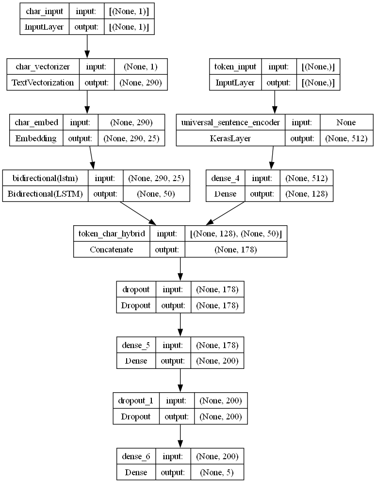

```python
# plot hybrid token and char embed model
from tensorflow.keras.utils import plot_model
plot_model(model_4, show_shapes=True, show_layer_names=True)
```

The model flowchart now gives a good idea of how the layers are connecting.

```python
# compile token char model
model_4.compile(loss='categorical_crossentropy',
optimizer=tf.keras.optimizers.Adam(),
metrics=['accuracy'])
```

Again using 10% of training and validation data. The other difference, is using the sentence and character sequenced data.

### Combining token and character data into a `tf.data` dataset

```python
# Combine chars and tokens into a dataset
train_char_token_data = tf.data.Dataset.from_tensor_slices((train_sentences, train_chars)) # make data
train_char_token_labels = tf.data.Dataset.from_tensor_slices(train_labels_one_hot) # make labels
train_char_token_dataset = tf.data.Dataset.zip((train_char_token_data, train_char_token_labels)) # combine data and labels

# Prefetch and batch train data
train_char_token_dataset = train_char_token_dataset.batch(32).prefetch(tf.data.AUTOTUNE)

# Repeat same steps validation data
val_char_token_data = tf.data.Dataset.from_tensor_slices((val_sentences, val_chars))
val_char_token_labels = tf.data.Dataset.from_tensor_slices(val_labels_one_hot)
val_char_token_dataset = tf.data.Dataset.zip((val_char_token_data, val_char_token_labels))
val_char_token_dataset = val_char_token_dataset.batch(32).prefetch(tf.data.AUTOTUNE)
```

```python
# Check out training char and token embedding dataset
train_char_token_dataset, val_char_token_dataset
```

```
(<_PrefetchDataset element_spec=((TensorSpec(shape=(None,), dtype=tf.string, name=None), TensorSpec(shape=(None,), dtype=tf.string, name=None)), TensorSpec(shape=(None, 5), dtype=tf.float64, name=None))>,
 <_PrefetchDataset element_spec=((TensorSpec(shape=(None,), dtype=tf.string, name=None), TensorSpec(shape=(None,), dtype=tf.string, name=None)), TensorSpec(shape=(None, 5), dtype=tf.float64, name=None))>)
```

### Fitting a model on token and character-level sequences

```python
# fit the model on tokens and chars
model_4_history = model_4.fit(train_char_token_dataset, # train on dataset of token and characters
                              steps_per_epoch=int(0.1*len(train_char_token_dataset)),
                              epochs=3,
                              validation_data=val_char_token_dataset,
                              validation_steps=int(0.1*len(val_char_token_dataset)))
```

```python
# evaluate on the whole validation dataset
model_4.evaluate(val_char_token_dataset)
```

```
[0.6876916885375977, 0.7375215291976929]
```

```python
# make prediction using model
model_4_pred_probs = model_4.predict(val_char_token_dataset)
model_4_pred_probs
```

```
array([[4.3878475e-01, 3.4282973e-01, 3.4764828e-03, 2.0592894e-01,
        8.9800712e-03],
       [3.2473576e-01, 4.8192710e-01, 2.6598731e-03, 1.8783222e-01,
        2.8450622e-03],
       [3.2050103e-01, 1.6689362e-01, 4.6623800e-02, 4.2656457e-01,
        3.9416991e-02],
       ...,
       [5.2287837e-04, 6.1629284e-03, 8.8115647e-02, 1.9909274e-04,
        9.0499943e-01],
       [6.7212875e-03, 4.5027055e-02, 2.1470638e-01, 2.8760163e-03,
        7.3066926e-01],
       [2.3625419e-01, 3.0482146e-01, 3.6315259e-01, 3.8742639e-02,
        5.7029087e-02]], dtype=float32)
```

```python
# turn prediction probabilities into class preds
model_4_preds = tf.argmax(model_4_pred_probs,axis=1)
model_4_preds
```

```
<tf.Tensor: shape=(30212,), dtype=int64, numpy=array([0, 1, 3, ..., 4, 4, 2], dtype=int64)>
```

```python
# get results of model
model_4_results = calculate_results(y_true=val_labels_encoded,
                                    y_pred=model_4_preds)
model_4_results
```

```
{'accuracy': 73.75215146299485,
 'precision': 0.7380677222477386,
 'recall': 0.7375215146299484,
 'f1': 0.7344838859171651}
```

### Model 5: Transfer Learning with pretrained token embeddings + character embeddings + positional embeddings

Token and Character embedding proved fruitful with `model_4`. But we are able to feature engineer another way, to give the model more information about our samples.

If we were to look at a single abstract, would we expectg a specific order to appear per sentence? For example `CONCLUSIONS` located at the end, or `OBJECTIVE` labeled at the start of the sequence?

They come in orders such as:

- OBJECTIVE ...
- METHODS ...
- METHODS ...
- METHODS ...
- RESULTS ...
- CONCLUSIONS ...

Or

- BACKGROUND ...
- OBJECTIVE ...
- METHODS ...
- METHODS ...
- RESULTS ...
- RESULTS ...
- CONCLUSIONS ...
- CONCLUSIONS ...

Obviously we can't feature engineer the names of the label, or else we cause data leakage and defeat the purpose of the model learning. However we can encode position of the setence in the abstract such as:

- Sentence 1 of 10 ...
- Sentence 2 of 10 ...
- Sentence 3 of 10 ...
- Sentence 4 of 10 ...
- ...

This is fortunately already formed back when we did `preprocess_text_with_line_numbers()` function. When we read the entire dataset ob abstracts, we also counted the number of lines per abstract, and the line number itself.

Doing this lead to `line_number` and `total_lines` columns in dataframe.

```python
# inspect training dataframe
train_df.head()
```

|  | target | text | line_number | total_lines |
| --- | --- | --- | --- | --- |
| 0 | OBJECTIVE | to investigate the efficacy of @ weeks of dail... | 0 | 11 |
| 1 | METHODS | a total of @ patients with primary knee oa wer... | 1 | 11 |
| 2 | METHODS | outcome measures included pain reduction and i... | 2 | 11 |
| 3 | METHODS | pain was assessed using the visual analog pain... | 3 | 11 |
| 4 | METHODS | secondary outcome measures included the wester... | 4 | 11 |

We can pass those two columns into our model as **positional embedding**. The positional embedding is where the sentence appears in the abstract.

[figure not shown]

*Our abstract has a sequential like order to othen (e.g. background, objective, methods, results, conclusion), which makes sense to add line number of where particular sentence occurs to our model. This is a feature that's also accessible and generatable from test data. (As all we need is to count the amount of lines in an abstract, and numerically count down per line).*

Another way we can create this feature, is combining `line_number` and `total_lines` into one column called `line_position`, e.g. `1 of 11`, `2 of 11` etc. We can try and test this and compare it to tow separate columns.

### Create positional embeddings

We can pass `line_number` and `total_line` as is to our model. But to avoid numerical thinking of determining `line_number=5` is five times greater than `line_number=1`, we'll use one hot encoding to encode both columns. We can use the `tf.one_hot` utility.

They return one hot encoded tensors, and accepts an array (or tensor) as input and the `depth` parameter determines the dimensions of the returned tensor.

To figure out what we should set our `depth` parameter to, let's check the `line_number` column.

```python
# how many different line numbers are there for all abstracts?
train_df['line_number'].value_counts()
```

```
line_number
0     15000
1     15000
2     15000
3     15000
4     14992
5     14949
6     14758
7     14279
8     13346
9     11981
10    10041
11     7892
12     5853
13     4152
```

[output cut: 18 more lines]

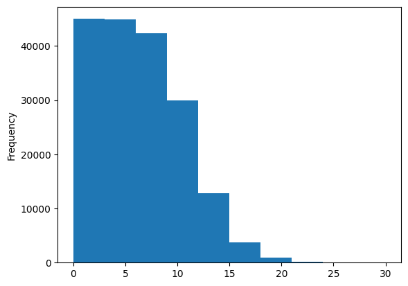

```python
# Check distribution of line_number column
train_df.line_number.plot.hist()
```

Majority of abstract's total lines are either 15 lines or below.

To preserve as much information, while reducing redundancy and zero padding, we will keep the `depth` parameter to 15, aka one hot encoding up to 15 lines of number.

```python
# use tendorflow to create on hot encoded tensors of our `line_number` column
train_line_numbers_one_hot = tf.one_hot(train_df['line_number'].to_numpy(),depth=15)
val_line_numbers_one_hot = tf.one_hot(val_df['line_number'].to_numpy(),depth=15)
test_line_numbers_one_hot = tf.one_hot(test_df['line_number'].to_numpy(),depth=15)
```

Any lines 15 and under, will receive the `1` in the one hot encoding as usual. However anything above 15 lines, will have one hot encoding columns filled with `0`.

```python
# check one hot encoded 'line_number' feature samples
train_line_numbers_one_hot.shape,train_line_numbers_one_hot[:20]
```

```
(TensorShape([180040, 15]),
 <tf.Tensor: shape=(20, 15), dtype=float32, numpy=
 array([[1., 0., 0., 0., 0., 0., 0., 0., 0., 0., 0., 0., 0., 0., 0.],
        [0., 1., 0., 0., 0., 0., 0., 0., 0., 0., 0., 0., 0., 0., 0.],
        [0., 0., 1., 0., 0., 0., 0., 0., 0., 0., 0., 0., 0., 0., 0.],
        [0., 0., 0., 1., 0., 0., 0., 0., 0., 0., 0., 0., 0., 0., 0.],
        [0., 0., 0., 0., 1., 0., 0., 0., 0., 0., 0., 0., 0., 0., 0.],
        [0., 0., 0., 0., 0., 1., 0., 0., 0., 0., 0., 0., 0., 0., 0.],
        [0., 0., 0., 0., 0., 0., 1., 0., 0., 0., 0., 0., 0., 0., 0.],
        [0., 0., 0., 0., 0., 0., 0., 1., 0., 0., 0., 0., 0., 0., 0.],
        [0., 0., 0., 0., 0., 0., 0., 0., 1., 0., 0., 0., 0., 0., 0.],
        [0., 0., 0., 0., 0., 0., 0., 0., 0., 1., 0., 0., 0., 0., 0.],
        [0., 0., 0., 0., 0., 0., 0., 0., 0., 0., 1., 0., 0., 0., 0.],
        [0., 0., 0., 0., 0., 0., 0., 0., 0., 0., 0., 1., 0., 0., 0.],
        [1., 0., 0., 0., 0., 0., 0., 0., 0., 0., 0., 0., 0., 0., 0.],
        [0., 1., 0., 0., 0., 0., 0., 0., 0., 0., 0., 0., 0., 0., 0.],
        [0., 0., 1., 0., 0., 0., 0., 0., 0., 0., 0., 0., 0., 0., 0.],
        [0., 0., 0., 1., 0., 0., 0., 0., 0., 0., 0., 0., 0., 0., 0.],
        [0., 0., 0., 0., 1., 0., 0., 0., 0., 0., 0., 0., 0., 0., 0.],
        [0., 0., 0., 0., 0., 1., 0., 0., 0., 0., 0., 0., 0., 0., 0.],
        [0., 0., 0., 0., 0., 0., 1., 0., 0., 0., 0., 0., 0., 0., 0.],
        [0., 0., 0., 0., 0., 0., 0., 1., 0., 0., 0., 0., 0., 0., 0.]],
       dtype=float32)>)
```

We can do the same for our `line_number` column with `total_lines` columns. Let's first find an appropriate value for the `depth` parameter on `tf.one_hot`.

```python
# how many different numbers of lines per abstract are there?
train_df['total_lines'].value_counts()
```

```
total_lines
11    24468
10    23639
12    22113
9     19400
13    18438
14    14610
8     12285
15    10768
7      7464
16     7429
17     5202
6      3353
18     3344
19     2480
20     1281
5      1146
21      770
22      759
23      264
4       215
24      200
25      182
26       81
28       58
3        32
30       31
27       28
Name: count, dtype: int64
```

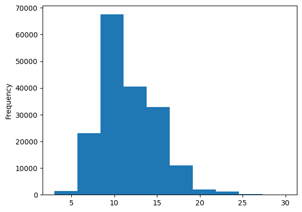

```python
# check distribution of total lines
train_df.total_lines.plot.hist();
```

Looking at distribution of our `total_lines` column, value of 20 and below appears to cover most samples.

We can confirm this with `np.percentile()`.

```python
# check the coverage of 'total_lines' when value is 20
np.percentile(train_df.total_lines,98) # does value of 20 cover 98% of samples?
```

```
20.0
```

That gives plenty of coverage, and do the same as we did for `line_number`.

```python
# use tensorflow to create one-hot encoded tensors of our `total_lines` column
train_total_lines_one_hot = tf.one_hot(train_df['total_lines'].to_numpy(),depth=20)
val_total_lines_one_hot = tf.one_hot(val_df['total_lines'].to_numpy(),depth=20)
test_total_lines_one_hot = tf.one_hot(test_df['total_lines'].to_numpy(),depth=20)

# check shape and samples of total lines one-hot tensor
train_total_lines_one_hot.shape,train_total_lines_one_hot[:20]
```

```
(TensorShape([180040, 20]),
 <tf.Tensor: shape=(20, 20), dtype=float32, numpy=
 array([[0., 0., 0., 0., 0., 0., 0., 0., 0., 0., 0., 1., 0., 0., 0., 0.,
         0., 0., 0., 0.],
        [0., 0., 0., 0., 0., 0., 0., 0., 0., 0., 0., 1., 0., 0., 0., 0.,
         0., 0., 0., 0.],
        [0., 0., 0., 0., 0., 0., 0., 0., 0., 0., 0., 1., 0., 0., 0., 0.,
         0., 0., 0., 0.],
        [0., 0., 0., 0., 0., 0., 0., 0., 0., 0., 0., 1., 0., 0., 0., 0.,
         0., 0., 0., 0.],
        [0., 0., 0., 0., 0., 0., 0., 0., 0., 0., 0., 1., 0., 0., 0., 0.,
         0., 0., 0., 0.],
        [0., 0., 0., 0., 0., 0., 0., 0., 0., 0., 0., 1., 0., 0., 0., 0.,
         0., 0., 0., 0.],
        [0., 0., 0., 0., 0., 0., 0., 0., 0., 0., 0., 1., 0., 0., 0., 0.,
         0., 0., 0., 0.],
        [0., 0., 0., 0., 0., 0., 0., 0., 0., 0., 0., 1., 0., 0., 0., 0.,
         0., 0., 0., 0.],
        [0., 0., 0., 0., 0., 0., 0., 0., 0., 0., 0., 1., 0., 0., 0., 0.,
         0., 0., 0., 0.],
        [0., 0., 0., 0., 0., 0., 0., 0., 0., 0., 0., 1., 0., 0., 0., 0.,
         0., 0., 0., 0.],
        [0., 0., 0., 0., 0., 0., 0., 0., 0., 0., 0., 1., 0., 0., 0., 0.,
         0., 0., 0., 0.],
        [0., 0., 0., 0., 0., 0., 0., 0., 0., 0., 0., 1., 0., 0., 0., 0.,
         0., 0., 0., 0.],
        [0., 0., 0., 0., 0., 0., 0., 0., 0., 0., 1., 0., 0., 0., 0., 0.,
         0., 0., 0., 0.],
        [0., 0., 0., 0., 0., 0., 0., 0., 0., 0., 1., 0., 0., 0., 0., 0.,
         0., 0., 0., 0.],
        [0., 0., 0., 0., 0., 0., 0., 0., 0., 0., 1., 0., 0., 0., 0., 0.,
         0., 0., 0., 0.],
        [0., 0., 0., 0., 0., 0., 0., 0., 0., 0., 1., 0., 0., 0., 0., 0.,
         0., 0., 0., 0.],
        [0., 0., 0., 0., 0., 0., 0., 0., 0., 0., 1., 0., 0., 0., 0., 0.,
         0., 0., 0., 0.],
        [0., 0., 0., 0., 0., 0., 0., 0., 0., 0., 1., 0., 0., 0., 0., 0.,
         0., 0., 0., 0.],
        [0., 0., 0., 0., 0., 0., 0., 0., 0., 0., 1., 0., 0., 0., 0., 0.,
         0., 0., 0., 0.],
        [0., 0., 0., 0., 0., 0., 0., 0., 0., 0., 1., 0., 0., 0., 0., 0.,
         0., 0., 0., 0.]], dtype=float32)>)
```

### Building a tribrid embedding model

Now its time to build a model that encompasses token, charavyer, and our new created positional embeddings. It may seem unfamiliar, but it's stuff we've practiced before.

We will go through the following steps:

1. Create a token-level model (similar to `model_1`)
2. Create a character-level model (similar to `model_3` with slight modification to reflect the paper)
3. Create a `line_number` model (takes one hot encoded `line_number` tensor and pass it through a non-linear layer)
4. Create a `total_lines` model (takes one hot encoded `total_lines` tensor and pass it through a non-linear layer)
5. Combine (using `layers.Concatenate`) the outputs of 1 and 2 into a token-character-hybrid embeding and pass it series of output.
6. Combines (using `layers.Concatenate`) the outputs of 3, 4 and 5 into a token-character-positional tribrid embedding
7. Create an output layer to accept the tribrid embedding and output predicted label probabilities
8. Combine the inputs of 1, 2, 3, 4 and outputs of 7 into a `tf.keras.Model`.

```python
# 1. Token inputs
token_inputs = layers.Input(shape=[],dtype='string',name='token_inputs')
token_embeddings = tf_hub_embedding_layer(token_inputs)
token_outputs = layers.Dense(128,activation='relu')(token_embeddings)
token_model = tf.keras.Model(inputs=token_inputs,outputs=token_outputs)

# 2. Char inputs
char_inputs = layers.Input(shape=(1,),dtype='string',name='char_inputs')
char_vector = char_vectorizer(char_inputs)
char_embeddings = char_embed(char_vector)
char_bi_lstm = layers.Bidirectional(layers.LSTM(32))(char_embeddings)
char_model = tf.keras.Model(inputs=char_inputs,outputs=char_bi_lstm)

# 3. Line number inputs
line_number_inputs = layers.Input(shape=(15,),dtype=tf.int32,name='line_number_input')
x = layers.Dense(32,activation='relu')(line_number_inputs)
line_number_model = tf.keras.Model(inputs=line_number_inputs,outputs=x)

# 4. Total lines inputs
total_lines_inputs = layers.Input(shape=(20,),dtype=tf.int32,name='total_lines_input')
x = layers.Dense(32,activation='relu')(total_lines_inputs)
total_line_model = tf.keras.Model(inputs=total_lines_inputs,outputs=x)

# 5. Combine token and char embedding into hybrid
combined_embeddings = layers.Concatenate(name='token_char_hybrid_embedding')([token_model.output,
                                                                              char_model.output])
z = layers.Dense(256,activation='relu')(combined_embeddings)
z = layers.Dropout(0.5)(z)

# 6. Combine positional embeddings with hybrid embed, making tribrid embedding
z = layers.Concatenate(name='token_char_pos_embedding')([line_number_model.output,
                                                         total_line_model.output,
                                                         z])

# 7. Create output layer
output_layer = layers.Dense(5, activation='softmax', name='output_layer')(z)

# 8. Put together model
model_5 = tf.keras.Model(inputs=[line_number_model.input,
                                 total_line_model.input,
                                 token_model.input,
                                 char_model.input],
                                 outputs=output_layer)
```

### Why the double wrapping of [[]] on token and character tokens?

Something I want to wrap my head about on the redundancy of having two [], when [] should be sufficient enough as it is when inputting into embedding for our models.

`TextVectorization` doesn't accept scalars by itself (aka single []). Because it also needs to know the `batch_size`. That outer [] wrapped around, states our batch having just one example.

Aka first[] = batch dimension, second[] = sequence dimension

```
# Character vectorization
Split text:
t h e   m e a n   c h a n g e   f r o m   b a s e l i n e   i n   m e a n   d i u r n a l   i o p   (   s t a n d a r d   d e v i a t i o n   )   i n   t h e   b i m a t o p r o s t / t i m o l o l   f i x e d   c o m b i n a t i o n   g r o u p   w a s   (   - @   @   )   m m h g   a n d   i t   w a s   (   - @   @   )   m m h g   i n   t h e   c o n c u r r e n t   g r o u p   (   p   <   @   )   .

Length of chars: 160

Vectorized chars:
[[ 3 13  2 15  2  5  6 11 13  5  6 18  2 17  8  7 15 22  5  9  2 12  4  6
   2  4  6 15  2  5  6 10  4 16  8  6  5 12  4  7 14  9  3  5  6 10  5  8
  10 10  2 21  4  5  3  4  7  6  4  6  3 13  2 22  4 15  5  3  7 14  8  7
   9  3  3  4 15  7 12  7 12 17  4 24  2 10 11  7 15 22  4  6  5  3  4  7
   6 18  8  7 16 14 20  5  9 15 15 13 18  5  6 10  4  3 20  5  9 15 15 13
  18  4  6  3 13  2 11  7  6 11 16  8  8  2  6  3 18  8  7 16 14 14  0  0
   0  0  0  0  0  0  0  0  0  0  0  0  0  0  0  0  0  0  0  0  0  0  0  0
   0  0  0  0  0  0  0  0  0  0  0  0  0  0  0  0  0  0  0  0  0  0  0  0
   0  0  0  0  0  0  0  0  0  0  0  0  0  0  0  0  0  0  0  0  0  0  0  0
   0  0  0  0  0  0  0  0  0  0  0  0  0  0  0  0  0  0  0  0  0  0  0  0
   0  0  0  0  0  0  0  0  0  0  0  0  0  0  0  0  0  0  0  0  0  0  0  0
   0  0  0  0  0  0  0  0  0  0  0  0  0  0  0  0  0  0  0  0  0  0  0  0
   0  0]]

# Token vecotrization
Text:
a treatment that does this , metacognitive therapy ( mct ) , underwent preliminary controlled evaluation in this study .

Length of text: 20

Vectorized text:
[[    8    19    28   711    23 11987    66  5987   352  1674   106   381
      5    23    17     0     0     0     0     0     0     0     0     0
      0     0     0     0     0     0     0     0     0     0     0     0
      0     0     0     0     0     0     0     0     0     0     0     0
      0     0     0     0     0     0     0]]
```

```python
# get summary of token, char, pos embed model
model_5.summary()
```

[output not shown]

[output cut: 8 more lines]

```

 dropout_4 (Dropout)         (None, 256)                  0         ['dense_19[0][0]']

 token_char_pos_embedding (  (None, 320)                  0         ['dense_17[0][0]',
 Concatenate)                                                        'dense_18[0][0]',
                                                                     'dropout_4[0][0]']

 output_layer (Dense)        (None, 5)                    1605      ['token_char_pos_embedding[0][
                                                                    0]']

==================================================================================================
Total params: 256932283 (980.12 MB)
Trainable params: 134459 (525.23 KB)
Non-trainable params: 256797824 (979.61 MB)
__________________________________________________________________________________________________
```

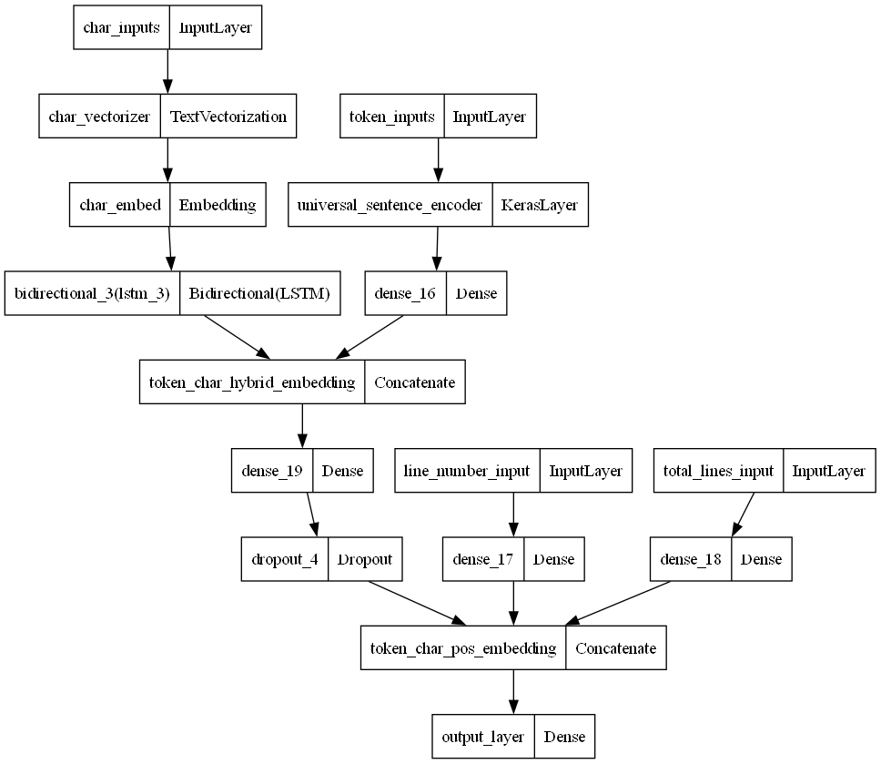

```python
# plot the token, char, pos embed model
from tensorflow.keras.utils import plot_model
plot_model(model_5)
```

Visualizing the model makes it easier to understand how it combines.

What we're doing on the above is encoding as much information about each sequence/sentence into various inputs to our model. That way our model has a better chance to figure out what label belongs to which sequence in the abstract.

```python
# check which layers of our model are trainable and which are not
for layer in model_5.layers:
    print(layer,layer.trainable)
```

```
<keras.src.engine.input_layer.InputLayer object at 0x000002B34299BBE0> True
<keras.src.engine.input_layer.InputLayer object at 0x000002B35EB494E0> True
<keras.src.layers.preprocessing.text_vectorization.TextVectorization object at 0x000002B3429AF910> True
<tensorflow_hub.keras_layer.KerasLayer object at 0x000002B28DADB490> False
<keras.src.layers.core.embedding.Embedding object at 0x000002B342B08400> True
<keras.src.layers.core.dense.Dense object at 0x000002B35EB49540> True
<keras.src.layers.rnn.bidirectional.Bidirectional object at 0x000002B342F50FA0> True
<keras.src.layers.merging.concatenate.Concatenate object at 0x000002B35E878AF0> True
<keras.src.engine.input_layer.InputLayer object at 0x000002B35EBC5BA0> True
<keras.src.engine.input_layer.InputLayer object at 0x000002B342C35CF0> True
<keras.src.layers.core.dense.Dense object at 0x000002B342C35480> True
<keras.src.layers.core.dense.Dense object at 0x000002B35E8A4F10> True
<keras.src.layers.core.dense.Dense object at 0x000002B34299B2E0> True
<keras.src.layers.regularization.dropout.Dropout object at 0x000002B35EB806A0> True
<keras.src.layers.merging.concatenate.Concatenate object at 0x000002B342C36E60> True
<keras.src.layers.core.dense.Dense object at 0x000002B35F0BF1F0> True
```

Time to compile the model.

We will introduce a new parameter to our loss function called `label_smoothing`. Label smoothing helps regularize our model and prevent overfitting by making sure it doesn't get too focused on applying one particular label to a sample.

For example an output prediction of:

`[0.0,0.0,1,0,0.0]` This prediction shows the model is very confident with index 2.

`[9.01,0.01,0.096,0.02]` Giving small activation to each of the other labels to in urn help improve generalization.

```python
# Compile token, char, pos, embed model
model_5.compile(loss=tf.keras.losses.CategoricalCrossentropy(label_smoothing=0.2), # add label smoothing to improve generalization
                optimizer=tf.keras.optimizers.Adam(),
                metrics=['accuracy'])
```

### Create tribrid embedding datasets and fit tribit model

we will fit the model with 20,000 examples in 3 epochs.

Our model requires four feature inputs:

1. Train line numbers one-hot encoded
2. Train total lines one-hot encoded
3. Token-level sequence tensor
4. Char-level sequence tensor

We can pass the tuples to our `tf.data.Dataset.from_tensor_slices()` method to create appropriately shaped and batched `PrefetchedDataset`.

```python
# create training and validation datasets
train_pos_char_token_data = tf.data.Dataset.from_tensor_slices((train_line_numbers_one_hot, # line numbers
                                                                train_total_lines_one_hot, # total lines
                                                                train_sentences, # train tokens
                                                                train_chars)) # train chars
train_pos_char_token_labels = tf.data.Dataset.from_tensor_slices(train_labels_one_hot) # train labels
train_pos_char_token_dataset = tf.data.Dataset.zip((train_pos_char_token_data,train_pos_char_token_labels)) # combine 4 datasets and labels
train_pos_char_token_dataset = train_pos_char_token_dataset.batch(32).prefetch(tf.data.AUTOTUNE) # turn into batches and prefetch appropriately

# validation data
val_pos_char_token_data = tf.data.Dataset.from_tensor_slices((val_line_numbers_one_hot,
                                                              val_total_lines_one_hot,
                                                              val_sentences,
                                                              val_chars))
val_pos_char_token_labels = tf.data.Dataset.from_tensor_slices(val_labels_one_hot)
val_pos_char_token_dataset = tf.data.Dataset.zip((val_pos_char_token_data, val_pos_char_token_labels))
val_pos_char_token_dataset = val_pos_char_token_dataset.batch(32).prefetch(tf.data.AUTOTUNE) # turn into batches and prefetch appropriately

# Check input shapes
train_pos_char_token_dataset, val_pos_char_token_dataset
```

```
(<_PrefetchDataset element_spec=((TensorSpec(shape=(None, 15), dtype=tf.float32, name=None), TensorSpec(shape=(None, 20), dtype=tf.float32, name=None), TensorSpec(shape=(None,), dtype=tf.string, name=None), TensorSpec(shape=(None,), dtype=tf.string, name=None)), TensorSpec(shape=(None, 5), dtype=tf.…
 <_PrefetchDataset element_spec=((TensorSpec(shape=(None, 15), dtype=tf.float32, name=None), TensorSpec(shape=(None, 20), dtype=tf.float32, name=None), TensorSpec(shape=(None,), dtype=tf.string, name=None), TensorSpec(shape=(None,), dtype=tf.string, name=None)), TensorSpec(shape=(None, 5), dtype=tf.…
```

```python
# Fit the token, char and positional embedding model
history_model_5 = model_5.fit(train_pos_char_token_dataset,
                              steps_per_epoch=int(0.1 * len(train_pos_char_token_dataset)),
                              epochs=3,
                              validation_data=val_pos_char_token_dataset,
                              validation_steps=int(0.1 * len(val_pos_char_token_dataset)))
```

```python
# make predictions with hybrid model
model_5_pred_probs = model_5.predict(val_pos_char_token_dataset,verbose=1)
model_5_pred_probs
```

```
array([[0.53105927, 0.11382025, 0.01049   , 0.32617384, 0.01845663],
       [0.55375713, 0.10362077, 0.0482047 , 0.28405428, 0.01036318],
       [0.2979154 , 0.10314483, 0.11425993, 0.41435546, 0.07032441],
       ...,
       [0.03467591, 0.08301466, 0.03402034, 0.02934908, 0.81894   ],
       [0.03022802, 0.3447897 , 0.08838056, 0.02349966, 0.51310205],
       [0.24225667, 0.5478306 , 0.10351849, 0.04051469, 0.06587958]],
      dtype=float32)
```

```python
# turn prediction probs into prediction classes
model_5_preds = tf.argmax(model_5_pred_probs,axis=1)
model_5_preds
```

```
<tf.Tensor: shape=(30212,), dtype=int64, numpy=array([0, 0, 3, ..., 4, 4, 1], dtype=int64)>
```

```python
# calculate results of hybrid model
model_5_results = calculate_results(val_labels_encoded,model_5_preds)
model_5_results
```

```
{'accuracy': 83.29802727393088,
 'precision': 0.8322275766152201,
 'recall': 0.8329802727393089,
 'f1': 0.8319548009961599}
```

### Compare model results

Our model results are in dictionaries, let's combine them into a pandas DataFrame to visualize them.

```python
# combine model results into a dataframe
all_model_results = pd.DataFrame({'baselines':baseline_results,
                                  'custom_token_embed_conv1d':model_1_results,
                                  'pretrained_token_embed':model_2_results,
                                  'custom_char_embed_conv1d':model_3_results,
                                  'hybrid_char_token_embed':model_4_results,
                                  'tribrid_pos_char_token_embed':model_5_results})
all_model_results = all_model_results.transpose() # swap column and rows for each other, so model names are on rows, and columns are the results
all_model_results
```

|  | accuracy | precision | recall | f1 |
| --- | --- | --- | --- | --- |
| baselines | 72.183238 | 0.718647 | 0.721832 | 0.698925 |
| custom_token_embed_conv1d | 78.829604 | 0.785867 | 0.788296 | 0.786135 |
| pretrained_token_embed | 71.273004 | 0.713185 | 0.712730 | 0.709796 |
| custom_char_embed_conv1d | 65.821528 | 0.652982 | 0.658215 | 0.648523 |
| hybrid_char_token_embed | 73.752151 | 0.738068 | 0.737522 | 0.734484 |
| tribrid_pos_char_token_embed | 83.298027 | 0.832228 | 0.832980 | 0.831955 |

```python
# reduce the accurace to same scale as other metrics
all_model_results['accuracy'] = all_model_results['accuracy']/100
```

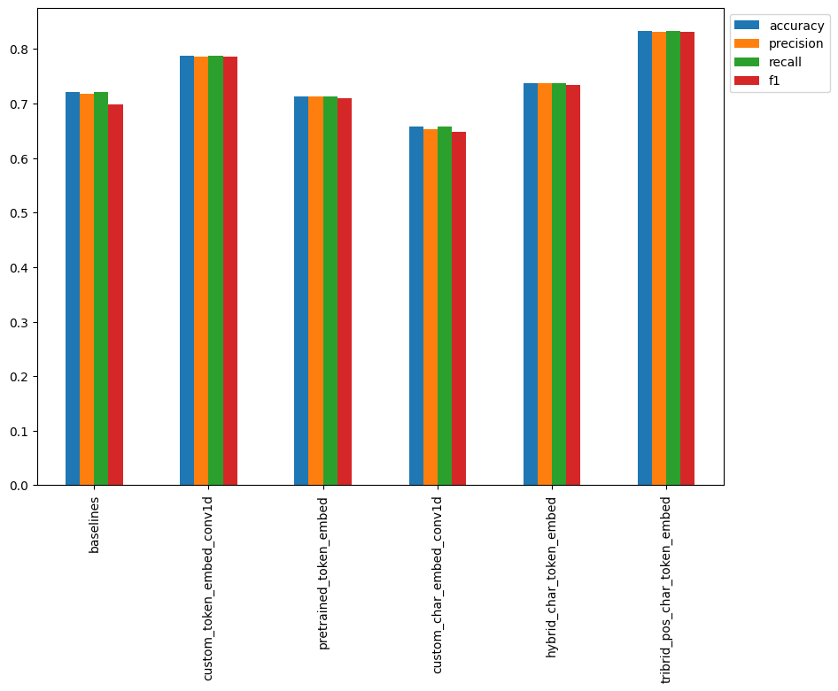

```python
# plot and compare all of the model results
all_model_results.plot(kind='bar',figsize=(10,7)).legend(bbox_to_anchor=(1,1));
```

let's also compare it by `f1-score`, as the paper does do comparison of it. Plus its a good balance between precision and recall results.

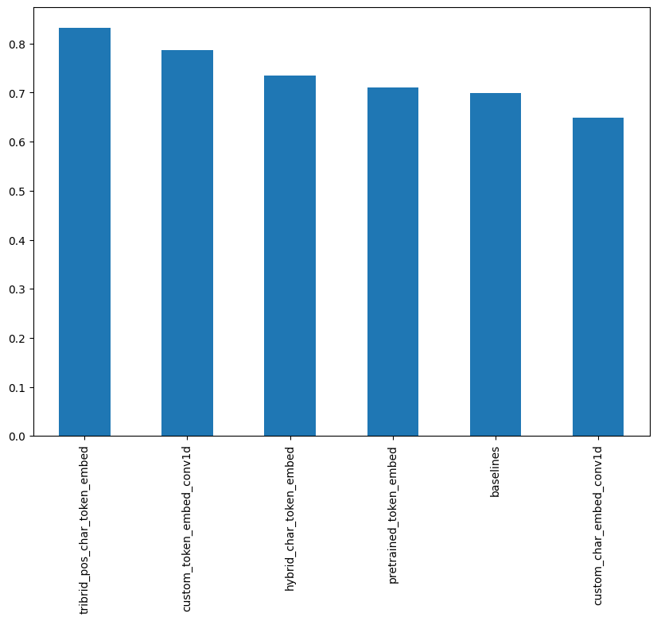

```python
# sort model results by f1-score
all_model_results.sort_values('f1',ascending=False)['f1'].plot(kind='bar',figsize=(10,7));
```

Our Tribrid model does the best overall performance by a fair margin.

In comparison to the tribrid formed in the paper, their `f1 score` is set at >90.0% compared to our lower 83.2%. Theres a few caveat to why it is lower:

Our model used 10% of the data, rather than the full 100%. We have done so this way to speed up experimentation, and get an idea on performance before upscaling to the full training dataset.

In addition, our data has been evaluated on the validation data, instead of the test data.

### Save and load best performing model

It's a good idea to save our best performing model so we can reuse it without need to retrain. We can save our best performing model by calling it `save()` method on it.

```python
# Save best performing model to SavedModel format (default)
model_5.save('skimlit_tribrid_model') # model will be saved to path specified by string
```

```
INFO:tensorflow:Assets written to: skimlit_tribrid_model\assets
```

```
INFO:tensorflow:Assets written to: skimlit_tribrid_model\assets
```

When loading in our model, since it uses a couple of custom objects (our TF Hub layer and `TextVectorization` layer), we'll have to load it in by specifying them in the `custom_objects` parameter of `tf.keras.models.load_model()`.

```python
# import tensorflow model dependencies (if needed)
import tensorflow_hub as hub
import tensorflow as tf
from tensorflow.keras.layers import TextVectorization

model_path = 'skimlit_tribrid_model/'

# load downloaded model
loaded_model = tf.keras.models.load_model(model_path)
```

### Make predictions and evaluate them against the truth labels

To make sure our model saved and loaded correctly, let's make predictions with it, evaluate them and then compare them to the prediction results we calculated earlier.

```python
# make predictions with the loaded model on the validate set
loaded_pred_probs = loaded_model.predict(val_pos_char_token_dataset,verbose=1)
loaded_preds = tf.argmax(loaded_pred_probs,axis=1)
loaded_preds[:10]
```

```
<tf.Tensor: shape=(10,), dtype=int64, numpy=array([0, 0, 3, 2, 2, 4, 4, 4, 4, 1], dtype=int64)>
```

```python
# evaluate loaded model's predictions
loaded_model_results =calculate_results(val_labels_encoded,
                                        loaded_preds)
loaded_model_results
```

```
{'accuracy': 83.29802727393088,
 'precision': 0.8322275766152201,
 'recall': 0.8329802727393089,
 'f1': 0.8319548009961599}
```

Now let's compare the loaded model to the tribrid model

```python
# compare loaded model results with original trained model results (should be quite close)
np.isclose(list(model_5_results.values()), list(loaded_model_results.values()), rtol=1e-02)
```

```
array([ True,  True,  True,  True])
```

```python
# check loaded model summary (note the number of training parameters)
loaded_model.summary()
```

[output not shown]

[output cut: 16 more lines]

```

 dropout_4 (Dropout)         (None, 256)                  0         ['dense_19[0][0]']

 token_char_pos_embedding (  (None, 320)                  0         ['dense_17[0][0]',
 Concatenate)                                                        'dense_18[0][0]',
                                                                     'dropout_4[0][0]']

 output_layer (Dense)        (None, 5)                    1605      ['token_char_pos_embedding[0][
                                                                    0]']

==================================================================================================
Total params: 256932283 (980.12 MB)
Trainable params: 134459 (525.23 KB)
Non-trainable params: 256797824 (979.61 MB)
__________________________________________________________________________________________________
```

### Evaluate model on test dataset

To make our model's performance more comparable with the results reported in Table 3 of the paper, let's make predictions on the test dataset and evaluate them.

```python
len(test_total_lines_one_hot)
```

```
30135
```

```python
# create test dataset batch and prefetched
test_pos_char_token_data = tf.data.Dataset.from_tensor_slices((test_line_numbers_one_hot,
                                                               test_total_lines_one_hot,
                                                               test_sentences,
                                                               test_chars))
test_pos_char_token_labels = tf.data.Dataset.from_tensor_slices(test_labels_one_hot)
test_pos_char_token_dataset = tf.data.Dataset.zip((test_pos_char_token_data,test_pos_char_token_labels))
test_pos_char_token_dataset = test_pos_char_token_dataset.batch(32).prefetch(tf.data.AUTOTUNE)

# check shapes
test_pos_char_token_dataset
```

```
<_PrefetchDataset element_spec=((TensorSpec(shape=(None, 15), dtype=tf.float32, name=None), TensorSpec(shape=(None, 20), dtype=tf.float32, name=None), TensorSpec(shape=(None,), dtype=tf.string, name=None), TensorSpec(shape=(None,), dtype=tf.string, name=None)), TensorSpec(shape=(None, 5), dtype=tf.f…
```

```python
# make predictions on the test dataset
test_pred_probs = loaded_model.predict(test_pos_char_token_dataset,verbose=1)
test_preds = tf.argmax(test_pred_probs,axis=1)
test_preds[:10]
```

```
<tf.Tensor: shape=(10,), dtype=int64, numpy=array([3, 0, 2, 2, 4, 4, 4, 1, 4, 0], dtype=int64)>
```

```python
# evaluate loaded model test predictions
loaded_model_test_results = calculate_results(y_true=test_labels_encoded,
                                              y_pred=test_preds)
loaded_model_test_results
```

```
{'accuracy': 82.73104363696699,
 'precision': 0.826056735452017,
 'recall': 0.8273104363696698,
 'f1': 0.8261888638564293}
```

It seems our model still has some amount to catch up to ~90.0 percent from the paper, compared to our 82.6%.

However again, we are using about 20,000, rather than the full 180,000 sequences. But we also haven't fine-tuned the pretrained embeddings. So there's a couple of extensions we could try to improve our results.

### Find most wrong

One of the best ways to investigate where your model is going wrong (or potentially where your data is wrong) is to visualize the 'most wrong' predictions.

Most wrong predictions are samples where the model has made a predictionn with a high probability but has gotten it wrong (the model's prediction disagrees with the ground truth label).

Looking at the most wrong predictions can give us valuable information on how to improve further models or fix the labels in our data.

Let's write some code to help us visualize the most wrong predictions from the test dataset.

First we'll convert all of our integer-based test predictions into their string-based class names.

```python
%%time
# get list of class names of test predictions
test_pred_classes = [label_encoder.classes_[pred] for pred in test_preds]
test_pred_classes[:10]
```

```
CPU times: total: 7.61 s
Wall time: 7.93 s
```

```
['OBJECTIVE',
 'BACKGROUND',
 'METHODS',
 'METHODS',
 'RESULTS',
 'RESULTS',
 'RESULTS',
 'CONCLUSIONS',
 'RESULTS',
 'BACKGROUND']
```

Now we'll add extra details regarding the `most wrong`.

- A `'prediction'` (string) column, containing model's prediction of sample
- A `'pred_prob'` (float) column, containing model's maximum prediction probability of sample
- A `'correct'` (boolean) column, indicating whether prediction made was correct or not

```python
# create prediction test dataframe
test_df['prediction'] = test_pred_classes # create column with test pred class names
test_df['pred_prob'] = tf.reduce_max(test_pred_probs,axis=1).numpy() # get maximum pred probs
test_df['correct'] = test_df['prediction'] == test_df['target'] # create binary column for whether preds is correct or not
test_df.head(20)
```

|  | target | text | line_number | total_lines | prediction | pred_prob | correct |
| --- | --- | --- | --- | --- | --- | --- | --- |
| 0 | BACKGROUND | this study analyzed liver function abnormaliti... | 0 | 8 | OBJECTIVE | 0.448219 | False |
| 1 | RESULTS | a post hoc analysis was conducted with the use... | 1 | 8 | BACKGROUND | 0.371766 | False |
| 2 | RESULTS | liver function tests ( lfts ) were measured at... | 2 | 8 | METHODS | 0.776355 | False |
| 3 | RESULTS | survival analyses were used to assess the asso... | 3 | 8 | METHODS | 0.556317 | False |
| 4 | RESULTS | the percentage of patients with abnormal lfts ... | 4 | 8 | RESULTS | 0.693611 | True |
| 5 | RESULTS | when mean hemodynamic profiles were compared i... | 5 | 8 | RESULTS | 0.882957 | True |
| 6 | RESULTS | multivariable analyses revealed that patients ... | 6 | 8 | RESULTS | 0.558802 | True |
| 7 | CONCLUSIONS | abnormal lfts are common in the adhf populatio... | 7 | 8 | CONCLUSIONS | 0.528578 | True |
| 8 | CONCLUSIONS | elevated meld-xi scores are associated with po... | 8 | 8 | RESULTS | 0.458830 | False |
| 9 | BACKGROUND | minimally invasive endovascular aneurysm repai... | 0 | 12 | BACKGROUND | 0.564277 | True |
| 10 | BACKGROUND | the aim of this study was to analyse the cost-... | 1 | 12 | OBJECTIVE | 0.476073 | False |
| 11 | METHODS | resource use was determined from the amsterdam... | 2 | 12 | METHODS | 0.556314 | True |
| 12 | METHODS | the analysis was performed from a provider per... | 3 | 12 | METHODS | 0.861847 | True |
| 13 | METHODS | all costs were calculated as if all patients h... | 4 | 12 | METHODS | 0.543667 | True |
| 14 | RESULTS | a total of @ patients were randomized . | 5 | 12 | RESULTS | 0.715481 | True |
| 15 | RESULTS | the @-day mortality rate was @ per cent after ... | 6 | 12 | RESULTS | 0.612739 | True |
| 16 | RESULTS | at @months , the total mortality rate for evar... | 7 | 12 | RESULTS | 0.884687 | True |
| 17 | RESULTS | the mean cost difference between evar and or w... | 8 | 12 | RESULTS | 0.863906 | True |
| 18 | RESULTS | the incremental cost-effectiveness ratio per p... | 9 | 12 | RESULTS | 0.814921 | True |
| 19 | RESULTS | there was no significant difference in quality... | 10 | 12 | RESULTS | 0.762877 | True |

As a dataframe, now it's easy to manipulate it the way we want it - let's try sorting it by highest `'pred_prob'`, where it is only wrong predictions using `'correct' == False`.

```python
# find top 100 most wrong samples (100 is just arbitrary starting number)
top_100_wrong = test_df[test_df['correct'] == False].sort_values('pred_prob',ascending=False)[:100]
top_100_wrong
```

|  | target | text | line_number | total_lines | prediction | pred_prob | correct |
| --- | --- | --- | --- | --- | --- | --- | --- |
| 13874 | CONCLUSIONS | symptom outcomes will be assessed and estimate... | 4 | 6 | METHODS | 0.954916 | False |
| 2388 | RESULTS | the primary endpoint is the cumulative three-y... | 4 | 13 | METHODS | 0.939382 | False |
| 8545 | METHODS | pretest-posttest . | 1 | 11 | BACKGROUND | 0.936993 | False |
| 16347 | BACKGROUND | to evaluate the effects of the lactic acid bac... | 0 | 12 | OBJECTIVE | 0.916232 | False |
| 835 | BACKGROUND | to assess the temporal patterns of late gastro... | 0 | 11 | OBJECTIVE | 0.914649 | False |
| ... | ... | ... | ... | ... | ... | ... | ... |
| 12190 | CONCLUSIONS | clinicaltrials.gov nct@ . | 11 | 11 | BACKGROUND | 0.836280 | False |
| 12136 | RESULTS | for each individual enrolled as a case , we id... | 4 | 16 | METHODS | 0.836199 | False |
| 27935 | RESULTS | health status was measured by generic ( short ... | 4 | 8 | METHODS | 0.835893 | False |
| 29835 | CONCLUSIONS | by age @ years , subjects remained small and t... | 10 | 13 | RESULTS | 0.835503 | False |
| 2575 | CONCLUSIONS | clinicaltrials.gov : nct@ . | 10 | 10 | BACKGROUND | 0.834363 | False |

100 rows × 7 columns

Now that's produced, let's visualize the text

```python
# visualize top 100 wrong
for row in top_100_wrong[:10].itertuples():
    _,target,text,line_number,total_lines,prediction,pred_prob,_ = row
    print(f'Target: {target}, Pred: {prediction}, Line number: {line_number}, Total lines: {total_lines}\n')
    print(f'Text:\n{text}\n')
    print(f'---------\n')
```

```
Target: CONCLUSIONS, Pred: METHODS, Line number: 4, Total lines: 6

Text:
symptom outcomes will be assessed and estimates of cost-effectiveness made .

---------

Target: RESULTS, Pred: METHODS, Line number: 4, Total lines: 13

Text:
the primary endpoint is the cumulative three-year hiv incidence .

---------

Target: METHODS, Pred: BACKGROUND, Line number: 1, Total lines: 11

Text:
pretest-posttest .

---------

Target: BACKGROUND, Pred: OBJECTIVE, Line number: 0, Total lines: 12

Text:
to evaluate the effects of the lactic acid bacterium lactobacillus salivarius on caries risk factors .

---------

Target: BACKGROUND, Pred: OBJECTIVE, Line number: 0, Total lines: 11

Text:
to assess the temporal patterns of late gastrointestinal ( gi ) and genitourinary ( gu ) radiotherapy toxicity and resolution rates in a randomised controlled trial ( all-ireland cooperative oncology research group @-@ ) assessing duration of neo-adjuvant ( na ) hormone therapy for localised prostat…

---------

Target: CONCLUSIONS, Pred: BACKGROUND, Line number: 18, Total lines: 18

Text:
nct@ ( clinicaltrials.gov ) .

```

[output cut: 14 more lines]

```
---------

Target: RESULTS, Pred: BACKGROUND, Line number: 8, Total lines: 15

Text:
non-diffuse-trickling '' ) .

---------

Target: OBJECTIVE, Pred: METHODS, Line number: 4, Total lines: 27

Text:
second , we collected patient-reported outcomes for balance confidence and falls control .

---------
```

Looking at the most wrong predictions, does the model make silly mistakes, or are some labels attached to the sentence is incorrect or ambiguous.

A possible next step can be changing the inconsistent labels. The process of inferencing model prediction to help improve/investigate your dataset's labels/targets, is often referred as **active learning**.

### Make in the wild predictions

Since we've done some predictions over the test dataset, it would also be good to try the model on data that's in the wild. So we will find an abstract from PubMed, preprocess the text so it works with the model, then pass each sequence in the wild abstract through our model, to see what labels it predicts. Though quite a lot of abstracts are already preformatted into separate sections, which helps with readability.

We will use the following unstructured abstract:

> This RCT examined the efficacy of a manualized social intervention for children with HFASDs. Participants were randomly assigned to treatment or wait-list conditions. Treatment included instruction and therapeutic activities targeting social skills, face-emotion recognition, interest expansion, and interpretation of non-literal language. A response-cost program was applied to reduce problem behaviors and foster skills acquisition. Significant treatment effects were found for five of seven primary outcome measures (parent ratings and direct child measures). Secondary measures based on staff ratings (treatment group only) corroborated gains reported by parents. High levels of parent, child and staff satisfaction were reported, along with high levels of treatment fidelity. Standardized effect size estimates were primarily in the medium and large ranges and favored the treatment group.

This wall of text looks quite intimidating, or even fatiguing if you are a researcher, trying to skim for relevant literature.

Let's try the abstract on `model_5`.

Before that, we'll perform the following steps to preprocess the text appropriately:

1. Split it into sentences (lines).
2. Split it into characters.
3. Find the number of each line.
4. Find the total number of lines.

We can split the text to sentences via identifying `.`, though can present issues such as decimal points.

One way to solve this is leverage `spaCy's` `sentencizer` class, an easy to use sentence splitter based on what the NLP knows.

There is a prepeared batch of RTC abstract we will download from github.

```python
import json
# download and open example abstracts (copy and pasted from PubMed)
!curl -L -o skimlit_example_abstracts.json https://raw.githubusercontent.com/mrdbourke/tensorflow-deep-learning/main/extras/skimlit_example_abstracts.json

with open('skimlit_example_abstracts.json','r') as f:
    example_abstracts = json.load(f)

example_abstracts
```

```
  % Total    % Received % Xferd  Average Speed   Time    Time     Time  Current
                                 Dload  Upload   Total   Spent    Left  Speed

  0     0    0     0    0     0      0      0 --:--:-- --:--:-- --:--:--     0
100  6737  100  6737    0     0  14130      0 --:--:-- --:--:-- --:--:-- 14213
```

```
[{'abstract': 'This RCT examined the efficacy of a manualized social intervention for children with HFASDs. Participants were randomly assigned to treatment or wait-list conditions. Treatment included instruction and therapeutic activities targeting social skills, face-emotion recognition, interest …
  'source': 'https://pubmed.ncbi.nlm.nih.gov/20232240/',
  'details': 'RCT of a manualized social treatment for high-functioning autism spectrum disorders'},
 {'abstract': "Postpartum depression (PPD) is the most prevalent mood disorder associated with childbirth. No single cause of PPD has been identified, however the increased risk of nutritional deficiencies incurred through the high nutritional requirements of pregnancy may play a role in the patholo…
  'source': 'https://pubmed.ncbi.nlm.nih.gov/28012571/',
  'details': 'Formatting removed (can be used to compare model to actual example)'},
 {'abstract': 'Mental illness, including depression, anxiety and bipolar disorder, accounts for a significant proportion of global disability and poses a substantial social, economic and heath burden. Treatment is presently dominated by pharmacotherapy, such as antidepressants, and psychotherapy, su…
  'source': 'https://pubmed.ncbi.nlm.nih.gov/28942748/',
  'details': 'Effect of nutrition on mental health'},
 {'abstract': "Hepatitis C virus (HCV) and alcoholic liver disease (ALD), either alone or in combination, count for more than two thirds of all liver diseases in the Western world. There is no safe level of drinking in HCV-infected patients and the most effective goal for these patients is total abs…
  'source': 'https://pubmed.ncbi.nlm.nih.gov/22244707/',
  'details': 'Baclofen promotes alcohol abstinence in alcohol dependent cirrhotic patients with hepatitis C virus (HCV) infection'}]
```

```python
# see what our abstracts look like
abstracts = pd.DataFrame(example_abstracts)
abstracts
```

|  | abstract | source | details |
| --- | --- | --- | --- |
| 0 | This RCT examined the efficacy of a manualized... | https://pubmed.ncbi.nlm.nih.gov/20232240/ | RCT of a manualized social treatment for high-... |
| 1 | Postpartum depression (PPD) is the most preval... | https://pubmed.ncbi.nlm.nih.gov/28012571/ | Formatting removed (can be used to compare mod... |
| 2 | Mental illness, including depression, anxiety ... | https://pubmed.ncbi.nlm.nih.gov/28942748/ | Effect of nutrition on mental health |
| 3 | Hepatitis C virus (HCV) and alcoholic liver di... | https://pubmed.ncbi.nlm.nih.gov/22244707/ | Baclofen promotes alcohol abstinence in alcoho... |

With these example abstracts, let's try it on the trained model. But first, we need `spaCy` to turn it from a big chunk of text into sentences.

```python
import sys
!{sys.executable} -m pip install spacy
```

[output not shown]

[output cut: 79 more lines]

[output not shown]

[output not shown]

```python
# create sentencizer - Source: https://spacy.io/usage/linguistic-features#sbd
import spacy
from spacy.lang.en import English
nlp = English() # setup english sentence parser

# new version of spaCy
sentencizer = nlp.add_pipe('sentencizer') # create sentence splitting pipeline object

# create 'doc' of parsed sequences, change index for a different abstract
doc = nlp(example_abstracts[0]['abstract'])
abstract_lines = [str(sent) for sent in list(doc.sents)] # return detected sentences from doc in string type
abstract_lines
```

```
['This RCT examined the efficacy of a manualized social intervention for children with HFASDs.',
 'Participants were randomly assigned to treatment or wait-list conditions.',
 'Treatment included instruction and therapeutic activities targeting social skills, face-emotion recognition, interest expansion, and interpretation of non-literal language.',
 'A response-cost program was applied to reduce problem behaviors and foster skills acquisition.',
 'Significant treatment effects were found for five of seven primary outcome measures (parent ratings and direct child measures).',
 'Secondary measures based on staff ratings (treatment group only) corroborated gains reported by parents.',
 'High levels of parent, child and staff satisfaction were reported, along with high levels of treatment fidelity.',
 'Standardized effect size estimates were primarily in the medium and large ranges and favored the treatment group.']
```

It seems spacy did a good job at splitting the sentences correctly. Obviously, there'll be more complex ones that the function alone can't do, and may require more customized splitting techniques.

As splitting is done, let's write some code to count the lines in sequence, and it's total number of lines.

We can leverage the functionality of `preprocess_text_with_line_numbers()` function.

```python
# get total number of lines
total_lines = len(abstract_lines)

# go through each line in abstract and create a list of dictionaries containing features for each line
sample_lines = []

for i,line in enumerate(abstract_lines):
    sample_dict = {}
    sample_dict['text'] = str(line)
    sample_dict['line_number'] = i
    sample_dict['total_lines'] = total_lines - 1 # following index value, not numerative
    sample_lines.append(sample_dict)
sample_lines
```

```
[{'text': 'This RCT examined the efficacy of a manualized social intervention for children with HFASDs.',
  'line_number': 0,
  'total_lines': 7},
 {'text': 'Participants were randomly assigned to treatment or wait-list conditions.',
  'line_number': 1,
  'total_lines': 7},
 {'text': 'Treatment included instruction and therapeutic activities targeting social skills, face-emotion recognition, interest expansion, and interpretation of non-literal language.',
  'line_number': 2,
  'total_lines': 7},
 {'text': 'A response-cost program was applied to reduce problem behaviors and foster skills acquisition.',
  'line_number': 3,
  'total_lines': 7},
 {'text': 'Significant treatment effects were found for five of seven primary outcome measures (parent ratings and direct child measures).',
  'line_number': 4,
  'total_lines': 7},
 {'text': 'Secondary measures based on staff ratings (treatment group only) corroborated gains reported by parents.',
  'line_number': 5,
  'total_lines': 7},
 {'text': 'High levels of parent, child and staff satisfaction were reported, along with high levels of treatment fidelity.',
  'line_number': 6,
  'total_lines': 7},
 {'text': 'Standardized effect size estimates were primarily in the medium and large ranges and favored the treatment group.',
  'line_number': 7,
  'total_lines': 7}]
```

```python
# Get all line_number values from sample abstract
test_abstract_line_numbers = [line['line_number'] for line in sample_lines]

# one hot encode to same depth as training data, so model accepts right input shape
test_abstract_line_numbers_one_hot = tf.one_hot(test_abstract_line_numbers,depth=15)
test_abstract_line_numbers_one_hot
```

```
<tf.Tensor: shape=(8, 15), dtype=float32, numpy=
array([[1., 0., 0., 0., 0., 0., 0., 0., 0., 0., 0., 0., 0., 0., 0.],
       [0., 1., 0., 0., 0., 0., 0., 0., 0., 0., 0., 0., 0., 0., 0.],
       [0., 0., 1., 0., 0., 0., 0., 0., 0., 0., 0., 0., 0., 0., 0.],
       [0., 0., 0., 1., 0., 0., 0., 0., 0., 0., 0., 0., 0., 0., 0.],
       [0., 0., 0., 0., 1., 0., 0., 0., 0., 0., 0., 0., 0., 0., 0.],
       [0., 0., 0., 0., 0., 1., 0., 0., 0., 0., 0., 0., 0., 0., 0.],
       [0., 0., 0., 0., 0., 0., 1., 0., 0., 0., 0., 0., 0., 0., 0.],
       [0., 0., 0., 0., 0., 0., 0., 1., 0., 0., 0., 0., 0., 0., 0.]],
      dtype=float32)>
```

```python
# get all total_line values from sample abstract
test_abstract_total_lines = [line['total_lines'] for line in sample_lines]

# one hot code again
test_abstract_total_lines_one_hot = tf.one_hot(test_abstract_total_lines,depth=20)
test_abstract_total_lines_one_hot
```

```
<tf.Tensor: shape=(8, 20), dtype=float32, numpy=
array([[0., 0., 0., 0., 0., 0., 0., 1., 0., 0., 0., 0., 0., 0., 0., 0.,
        0., 0., 0., 0.],
       [0., 0., 0., 0., 0., 0., 0., 1., 0., 0., 0., 0., 0., 0., 0., 0.,
        0., 0., 0., 0.],
       [0., 0., 0., 0., 0., 0., 0., 1., 0., 0., 0., 0., 0., 0., 0., 0.,
        0., 0., 0., 0.],
       [0., 0., 0., 0., 0., 0., 0., 1., 0., 0., 0., 0., 0., 0., 0., 0.,
        0., 0., 0., 0.],
       [0., 0., 0., 0., 0., 0., 0., 1., 0., 0., 0., 0., 0., 0., 0., 0.,
        0., 0., 0., 0.],
       [0., 0., 0., 0., 0., 0., 0., 1., 0., 0., 0., 0., 0., 0., 0., 0.,
        0., 0., 0., 0.],
       [0., 0., 0., 0., 0., 0., 0., 1., 0., 0., 0., 0., 0., 0., 0., 0.,
        0., 0., 0., 0.],
       [0., 0., 0., 0., 0., 0., 0., 1., 0., 0., 0., 0., 0., 0., 0., 0.,
        0., 0., 0., 0.]], dtype=float32)>
```

Now time to split our abstract lines into individual characters with `split_char()`.

```python
# split abstract lines into characters
abstract_chars = [split_chars(sentence) for sentence in abstract_lines]
abstract_chars
```

```
['T h i s   R C T   e x a m i n e d   t h e   e f f i c a c y   o f   a   m a n u a l i z e d   s o c i a l   i n t e r v e n t i o n   f o r   c h i l d r e n   w i t h   H F A S D s .',
 'P a r t i c i p a n t s   w e r e   r a n d o m l y   a s s i g n e d   t o   t r e a t m e n t   o r   w a i t - l i s t   c o n d i t i o n s .',
 'T r e a t m e n t   i n c l u d e d   i n s t r u c t i o n   a n d   t h e r a p e u t i c   a c t i v i t i e s   t a r g e t i n g   s o c i a l   s k i l l s ,   f a c e - e m o t i o n   r e c o g n i t i o n ,   i n t e r e s t   e x p a n s i o n ,   a n d   i n t e r p r e t a t i o n   o …
 'A   r e s p o n s e - c o s t   p r o g r a m   w a s   a p p l i e d   t o   r e d u c e   p r o b l e m   b e h a v i o r s   a n d   f o s t e r   s k i l l s   a c q u i s i t i o n .',
 'S i g n i f i c a n t   t r e a t m e n t   e f f e c t s   w e r e   f o u n d   f o r   f i v e   o f   s e v e n   p r i m a r y   o u t c o m e   m e a s u r e s   ( p a r e n t   r a t i n g s   a n d   d i r e c t   c h i l d   m e a s u r e s ) .',
 'S e c o n d a r y   m e a s u r e s   b a s e d   o n   s t a f f   r a t i n g s   ( t r e a t m e n t   g r o u p   o n l y )   c o r r o b o r a t e d   g a i n s   r e p o r t e d   b y   p a r e n t s .',
 'H i g h   l e v e l s   o f   p a r e n t ,   c h i l d   a n d   s t a f f   s a t i s f a c t i o n   w e r e   r e p o r t e d ,   a l o n g   w i t h   h i g h   l e v e l s   o f   t r e a t m e n t   f i d e l i t y .',
 'S t a n d a r d i z e d   e f f e c t   s i z e   e s t i m a t e s   w e r e   p r i m a r i l y   i n   t h e   m e d i u m   a n d   l a r g e   r a n g e s   a n d   f a v o r e d   t h e   t r e a t m e n t   g r o u p .']
```

Now our preprocessing has done, with all relevant information, we can finally pass them onto our model, and make sequence label predictions.

```python
# make predictions on sample abstract features
test_abstract_pred_probs = loaded_model.predict(x=(test_abstract_line_numbers_one_hot,
                                                         test_abstract_total_lines_one_hot,
                                                         tf.constant(abstract_lines),
                                                         tf.constant(abstract_chars)))
test_abstract_pred_probs
```

```
array([[0.2737111 , 0.11912616, 0.01480955, 0.55936533, 0.0329879 ],
       [0.07758942, 0.03037473, 0.69385177, 0.10254083, 0.09564327],
       [0.10905726, 0.05330755, 0.56336117, 0.17471819, 0.09955582],
       [0.10740733, 0.14665343, 0.51358086, 0.08334783, 0.14901057],
       [0.05948103, 0.10527293, 0.40008047, 0.04746288, 0.38770264],
       [0.0303197 , 0.11948555, 0.51209503, 0.0409437 , 0.297156  ],
       [0.02996539, 0.20614074, 0.07335173, 0.02518941, 0.6653527 ],
       [0.01979202, 0.11458812, 0.28293324, 0.03112708, 0.5515595 ]],
      dtype=float32)
```

```python
# turn prediction probabilities into prediction classes
test_abstract_preds = tf.argmax(test_abstract_pred_probs,axis=1)
test_abstract_preds
```

```
<tf.Tensor: shape=(8,), dtype=int64, numpy=array([3, 2, 2, 2, 2, 2, 4, 4], dtype=int64)>
```

```python
# turn prediction class integers into class names
test_abstract_pred_class = [label_encoder.classes_[i] for i in test_abstract_preds]
test_abstract_pred_class
```

```
['OBJECTIVE',
 'METHODS',
 'METHODS',
 'METHODS',
 'METHODS',
 'METHODS',
 'RESULTS',
 'RESULTS']
```

```python
# visualize abstract lines and predicted sequence labels
for i,line in enumerate(abstract_lines):
    print(f'{test_abstract_pred_class[i]}: {line}')
```

```
OBJECTIVE: This RCT examined the efficacy of a manualized social intervention for children with HFASDs.
METHODS: Participants were randomly assigned to treatment or wait-list conditions.
METHODS: Treatment included instruction and therapeutic activities targeting social skills, face-emotion recognition, interest expansion, and interpretation of non-literal language.
METHODS: A response-cost program was applied to reduce problem behaviors and foster skills acquisition.
METHODS: Significant treatment effects were found for five of seven primary outcome measures (parent ratings and direct child measures).
METHODS: Secondary measures based on staff ratings (treatment group only) corroborated gains reported by parents.
RESULTS: High levels of parent, child and staff satisfaction were reported, along with high levels of treatment fidelity.
RESULTS: Standardized effect size estimates were primarily in the medium and large ranges and favored the treatment group.
```

Now reading looks much easier :)